# Cleantech RAG

By [Daniel Perruchoud](https://www.linkedin.com/in/daniel-olivier-perruchoud-799aaa38/) and [George Rowlands](https://www.linkedin.com/in/georgerowlands/)

## Introduction

This notebook delves into the exciting realm of Cleantech using a [dataset of nearly 10,000 news articles from Kaggle](https://www.kaggle.com/datasets/jannalipenkova/cleantech-media-dataset), all centered around the energy sector. We'll embark on a journey that includes data exploration, text preprocessing, and culminates in the creation of a Retrieval-Augmented Generation Pipeline (RAG). This powerful approach empowers us to construct an LLM (Large Language Model) that can intelligently answer user queries, drawing upon the knowledge from our curated news articles.

### Why RAG? A Cost-Effective and Dynamic Solution

Fine-tuning an LLM can be a resource-intensive and inflexible process. RAG offers a compelling alternative. It leverages a semantic search to pinpoint relevant sections within our news articles that directly address a user's question. These retrieved sections are then provided to the LLM as context, enabling it to deliver informed and insightful responses.

[figure not shown]

### Setup

To run this notebook we recommend downloading the provided [GitHub repository](https://github.com/LuciferUchiha/Cleantech-RAG) and opening this notebook in [Google Colab](https://colab.research.google.com/). To ensure a smooth experience, you'll need:

- An OpenAI API key for GPT-4o
- A Google account for Google Colab
- Python packages (automatically installed within the notebook)

At the start of the notebook a `data.zip` will be downloaded from a Google Drive and unzipped. This will then provide you with files that contain checkpoints for all of the expensive processing sections such as chunking, generating embeddings and evaluating the pipeline with an LLM as a judge. This saves you money and a lot of time.

If you can't or don't want to run this notebook you can also view the completed notebook by opening the `cleantech_rag.html` file in your browser.

### Unveiling the Depths of RAG Pipelines

Questions or Issues? We're Here to Help!

If you encounter any roadblocks or have questions, please don't hesitate to reach out to [George Rowlands](https://www.linkedin.com/in/georgerowlands/)

## Installing Dependencies

```python
%%writefile requirements.txt

chromadb==0.5.0
datasets==2.19.1
gdown==5.2.0
kaggle==1.6.1
langchain==0.3.10
langchain-community==0.3.10
langchain-experimental==0.3.3
langchain-openai==0.2.12
langdetect==1.0.9
lorem-text==2.1
nbformat>=4.2.0
openai==1.57.1
plotly==5.22.0
pretty-jupyter==1.0
ragas==0.1.8
seaborn==0.13.2
sentence-transformers==3.0.0
spacy>=3.7
textstat==0.7.3
umap-learn==0.5.5
```

```
Writing requirements.txt
```

```python
%pip install torch==2.5.1 --quiet --index-url https://download.pytorch.org/whl/cu121
```

[output not shown]

```python
%pip install -r ./requirements.txt --quiet
```

[output not shown]

```python
!pip install --upgrade fsspec==2025.3.0
```

[output not shown]

```python
!pip check
```

```
datasets 2.19.1 has requirement fsspec[http]<=2024.3.1,>=2023.1.0, but you have fsspec 2025.3.0.
torchaudio 2.6.0+cu124 has requirement torch==2.6.0, but you have torch 2.5.1+cu121.
torchvision 0.21.0+cu124 has requirement torch==2.6.0, but you have torch 2.5.1+cu121.
gcsfs 2025.3.2 has requirement fsspec==2025.3.2, but you have fsspec 2025.3.0.
```

```python
# restart the session after this
!pip install --upgrade --force-reinstall gcsfs fsspec
```

[output not shown]

[output cut: 141 more lines]

[output not shown]

```python
!pip uninstall torch torchvision -y
!pip install torch torchvision torchaudio --index-url https://download.pytorch.org/whl/cu118
```

[output not shown]

# import libraries

```python
import json
import os
import warnings
import zipfile
from collections import Counter
from pathlib import Path
from typing import Dict, List

import chromadb
import matplotlib.pyplot as plt
import numpy as np
import pandas as pd
import plotly.express as px
import plotly.graph_objects as go
import plotly.io as pio
import seaborn as sns
import torch
from chromadb import Collection, Documents, EmbeddingFunction, Embeddings
from datasets import Dataset
from dotenv import load_dotenv
from langdetect import detect
from lorem_text import lorem
from ragas import RunConfig, evaluate
from ragas.metrics import (faithfulness, answer_relevancy, context_relevancy, answer_correctness)
from spacy.lang.en import English
from textstat import flesch_reading_ease
from tqdm import tqdm
import umap
```

```python
import umap
from langchain.chains.base import Chain
from langchain.chains import LLMChain
from langchain.text_splitter import RecursiveCharacterTextSplitter, TextSplitter
from langchain_community.embeddings import HuggingFaceEmbeddings
from langchain_community.vectorstores import Chroma, VectorStore
from langchain_core.callbacks import CallbackManagerForRetrieverRun
from langchain_core.documents import Document
from langchain_core.embeddings import Embeddings
from langchain_core.language_models import LLM
from langchain_core.output_parsers import StrOutputParser
from langchain_core.prompts import ChatPromptTemplate
from langchain_core.retrievers import BaseRetriever
from langchain_core.runnables import RunnableParallel, RunnablePassthrough
from langchain_experimental.text_splitter import SemanticChunker
from langchain_openai import ChatOpenAI, OpenAIEmbeddings

load_dotenv()
warnings.filterwarnings("ignore")
```

By removing the first line from the two cells below, you can download the dataset, chunks, embeddings of the chunks and evaluation results from our Google Drive. This will save you time and money.

## Import the Data

```python
# %%script echo skipping
!gdown 1zEs4AkpyFBcaOZvF120LrDntOiuen8jC
data_path = './'
```

```python
import zipfile

with zipfile.ZipFile(f"{data_path}data.zip", "r") as zip_file:
    zip_file.extractall('./')
```

```python
data_folder = Path(f"data")
if not data_folder.exists():
    data_folder.mkdir()
bronze_folder = data_folder / "bronze"
if not bronze_folder.exists():
    bronze_folder.mkdir()
```

## Loading the Dataset into Dataframes

We now load and inspect both the Cleantech Media Dataset and the gold-standard evaluation data provided by our subject matter expert, Janna Lipenkova.

```python
silver_folder = data_folder / "silver"
if not silver_folder.exists():
    silver_folder.mkdir()
```

# Load Datasets

Media Dataset

```python
articles_df = pd.read_csv(
    silver_folder / "articles.csv",
    encoding='utf-8', index_col=0)
articles_df.head()
```

| title | content | domain | url | article | lang | readability |
| --- | --- | --- | --- | --- | --- | --- |
| XPeng Delivered ~100,000 Vehicles In 2021 | ['Chinese automotive startup XPeng has shown o... | cleantechnica | https://cleantechnica.com/2022/01/02/xpeng-del... | Chinese automotive startup XPeng has shown one... | en | 63.09 |
| Green Hydrogen: Drop In Bucket Or Big Splash? | ['Sinopec has laid plans to build the largest ... | cleantechnica | https://cleantechnica.com/2022/01/02/its-a-gre... | Sinopec has laid plans to build the largest gr... | en | 51.89 |
| World’ s largest floating PV plant goes online in China – pv magazine International | ['Huaneng Power International has switched on ... | pv-magazine | https://www.pv-magazine.com/2022/01/03/worlds-... | Huaneng Power International has switched on a ... | en | 55.13 |
| Iran wants to deploy 10 GW of renewables over the next four years – pv magazine International | ['According to the Iranian authorities, there ... | pv-magazine | https://www.pv-magazine.com/2022/01/03/iran-wa... | According to the Iranian authorities, there ar... | en | 52.90 |
| Eastern Interconnection Power Grid Said ‘ Being Challenged in New Ways’ | ['Sign in to get the best natural gas news and... | naturalgasintel | https://www.naturalgasintel.com/eastern-interc... | Daily GPI Infrastructure \| NGI All News Acces... | en | 23.46 |

Patent Dataset

```python
patents_df = pd.read_csv(
    silver_folder / "abstracts.csv",
    encoding='utf-8', index_col=0)
patents_df.head()
```

| publication_number | application_number | country_code | title | abstract | title_lang | abstract_lang | text | cleaned_text | topic | readability |
| --- | --- | --- | --- | --- | --- | --- | --- | --- | --- | --- |
| CN-117151396-A | CN-202311109834-A | CN | Distributed economic scheduling method for win... | The invention discloses a distributed economic... | en | en | Distributed economic scheduling method for win... | distributed economic scheduling method wind so... | 4 | -55.59 |
| CN-117147382-A | CN-202310985511-A | CN | Device for monitoring hydrogen atom crossing g... | The invention provides a device and a method f... | en | en | Device for monitoring hydrogen atom crossing g... | device monitoring hydrogen atom crossing grain... | 4 | -2.29 |
| CN-113344288-B | CN-202110717505-A | CN | Cascade hydropower station group water level p... | The invention discloses a cascade hydropower s... | en | en | Cascade hydropower station group water level p... | cascade hydropower station group water level p... | 8 | -34.10 |
| CN-117153944-A | CN-202311209193-A | CN | Heterojunction solar cell, preparation method ... | The application provides a heterojunction sola... | en | en | Heterojunction solar cell, preparation method ... | heterojunction solar cell preparation method t... | 6 | 6.21 |
| CN-116911695-B | CN-202311167289-A | CN | Flexible resource adequacy evaluation method a... | The invention relates to a flexible resource a... | en | en | Flexible resource adequacy evaluation method a... | flexible resource adequacy evaluation method d... | 8 | -35.49 |

## loading all evaluation datasets

```python
import pandas as pd

def load_csv(path, sep=None, on_bad_lines=None):
    kwargs = {
        "encoding": "utf-8",
    }
    if sep is not None:
        kwargs["sep"] = sep
    if on_bad_lines is not None:
        kwargs["on_bad_lines"] = on_bad_lines

    df = pd.read_csv(path, **kwargs)
    df.rename(columns={"relevant_chunk":"relevant_section","article_url": "url","source_doc": "url","Unnamed: 0":"id","context":"relevant_section"}, inplace=True)
    return df.drop(columns=["question_id"], errors="ignore")

# Dictionary of datasets: name → (filename, optional sep, optional on_bad_lines)
human_eval = {
    "human_eval": ("cleantech_rag_evaluation_data_2024-09-20.csv", ';', None),
    "media_cleaned": ("generated_questions_cleaned_media_llama.csv", None, None),
    "patent_cleaned": ("generated_questions_cleaned_patent_llama.csv", None, 'skip'),
    "media": ("QA_pairs_categorized_media_qa_df_llama.csv", None, None),
    "patent": ("QA_pairs_categorized_patent_qa_df_llama.csv", None, None),
}

# Load all datasets
human_eval_dfs = {}
for name, (filename, sep, on_bad_lines) in human_eval.items():
    path = bronze_folder / filename
    human_eval_dfs[name] = load_csv(path, sep=sep, on_bad_lines=on_bad_lines)
    # display(human_eval_dfs[name].head())

# Access like:
for name, df in human_eval_dfs.items():
    print(name)
    display(df.head())
```

```
human_eval
```

|  | example_id | question | relevant_text | answer | url |
| --- | --- | --- | --- | --- | --- |
| 0 | 1 | What is the innovation behind Leclanché's new ... | Leclanché said it has developed an environment... | Leclanché's innovation is using a water-based ... | https://www.sgvoice.net/strategy/technology/23... |
| 1 | 2 | What is the EU’s Green Deal Industrial Plan? | The Green Deal Industrial Plan is a bid by the... | The EU’s Green Deal Industrial Plan aims to en... | https://www.sgvoice.net/policy/25396/eu-seeks-... |
| 2 | 3 | What is the EU’s Green Deal Industrial Plan? | The European counterpart to the US Inflation R... | The EU’s Green Deal Industrial Plan aims to en... | https://www.pv-magazine.com/2023/02/02/europea... |
| 3 | 4 | What are the four focus areas of the EU's Gree... | The new plan is fundamentally focused on four ... | The four focus areas of the EU's Green Deal In... | https://www.sgvoice.net/policy/25396/eu-seeks-... |
| 4 | 5 | When did the cooperation between GM and Honda ... | What caught our eye was a new hookup between G... | July 2013 | https://cleantechnica.com/2023/05/08/general-m... |

```
media_cleaned
```

|  | id | relevant_section | question | answer | url | category | groundedness_score | groundedness_eval | relevance_score | relevance_eval | standalone_score | standalone_eval |
| --- | --- | --- | --- | --- | --- | --- | --- | --- | --- | --- | --- | --- |
| 0 | 0 | As we move toward a sustainable future, green ... | What is green hydrogen, and how is it produced? | Green hydrogen is a sustainable energy carrier... | https://www.azocleantech.com/article.aspx?Arti... | Sustainability & Technological Innovation Ques... | 5.0 | The provided context clearly explains what gre... | 3.0 | The question is straightforward and clear, inq... | 5.0 | The question is self-explanatory and does not ... |
| 1 | 5 | As we move toward a sustainable future, green ... | What is the significance of the Neom project i... | The Neom project, a partnership between ACWA P... | https://www.azocleantech.com/article.aspx?Arti... | Sustainability & Technological Innovation Ques... | 5.0 | The context provides a comprehensive overview ... | 4.0 | The Neom project is a key concept in the conte... | 4.0 | The question appears to rely on additional kno... |
| 2 | 8 | As we move toward a sustainable future, green ... | What is the significance of the Energy Transit... | The report highlights the need for a 30-year t... | https://www.azocleantech.com/article.aspx?Arti... | Sustainability & Technological Innovation Ques... | 5.0 | The question regarding the significance of the... | 3.0 | This question appears to be relevant to enviro... | 5.0 | The question refers to a specific institution ... |
| 3 | 10 | As we move toward a sustainable future, green ... | How does green hydrogen compare to direct use ... | Green hydrogen production through electrolysis... | https://www.azocleantech.com/article.aspx?Arti... | Sustainability & Technological Innovation Ques... | 4.0 | The question requires an in-depth analysis of ... | 4.0 | This question is relevant to NLP developers bu... | 5.0 | The question implies that there might be some ... |
| 4 | 14 | As we move toward a sustainable future, green ... | What are some of the examples of pilot project... | Various pilot projects are testing green hydro... | https://www.azocleantech.com/article.aspx?Arti... | Sustainability & Technological Innovation Ques... | 5.0 | The question can be answered unambiguously bas... | 3.0 | This question appears to be focused on environ... | 4.0 | The question asks for specific examples of pil... |

```
patent_cleaned
```

|  | id | relevant_section | question | answer | category | groundedness_score | groundedness_eval | relevance_score | relevance_eval | standalone_score | standalone_eval |
| --- | --- | --- | --- | --- | --- | --- | --- | --- | --- | --- | --- |
| 0 | 5 | Distributed photovoltaic energy storage refrig... | How does the system reduce the cost of cold st... | The system reduces the cost of cold storage by... | Sustainability & Technological Innovation Ques... | 5.0 | The question can be answered based on the give... | 4.0 | The question is concise and to the point, dire... | 5.0 | The question appears to be related to a genera... |
| 1 | 10 | Water path manifold structure of hydrogen ener... | What is good about the utility model? | The utility model has a simple structure that ... | Analytical & Explanatory Questions | 5.0 | The question "What is good about the utility m... | 3.0 | The question is very short and to the point, b... | 5.0 | The question seems to be asking about a genera... |
| 2 | 29 | Active power control method of water-fire-wind... | What is the purpose of using power supply with... | The power supply with better regulation perfor... | Government & Corporate Initiatives | 5.0 | The question is clearly answerable by understa... | 3.0 | The question is directly related to power supp... | 5.0 | The question assumes knowledge of power suppli... |
| 3 | 48 | Water conservancy and hydropower engineering c... | What is the water conservancy and hydropower e... | The utility model discloses a water conservanc... | Sustainability & Technological Innovation Ques... | 5.0 | The question is clearly answerable with the gi... | 3.0 | The question seems to be about a specific tech... | 5.0 | The question contains technical terms and a sp... |
| 4 | 61 | Medium-and-long-term electric power quantity b... | What is the main consideration for the balanci... | The seasonal characteristics of renewable ener... | Analytical & Explanatory Questions | 4.0 | The context provides a detailed description of... | 4.0 | The question is asking about a specific aspect... | 5.0 | The question does not provide a specific conte... |

```
media
```

|  | id | question | relevant_text | answer | url | category |
| --- | --- | --- | --- | --- | --- | --- |
| 0 | 0 | What is green hydrogen, and how is it produced? | As we move toward a sustainable future, green ... | Green hydrogen is a sustainable energy carrier... | https://www.azocleantech.com/article.aspx?Arti... | Sustainability & Technological Innovation Ques... |
| 1 | 1 | Who are some of the key players involved in th... | As we move toward a sustainable future, green ... | Key players include companies like Siemens Ene... | https://www.azocleantech.com/article.aspx?Arti... | Sustainability & Technological Innovation Ques... |
| 2 | 2 | What are the main challenges associated with i... | As we move toward a sustainable future, green ... | The main challenges include technical hurdles ... | https://www.azocleantech.com/article.aspx?Arti... | Sustainability & Technological Innovation Ques... |
| 3 | 3 | What is the role of the European Union's Hydro... | As we move toward a sustainable future, green ... | The strategy aims to significantly ramp up gre... | https://www.azocleantech.com/article.aspx?Arti... | Sustainability & Technological Innovation Ques... |
| 4 | 4 | How does the Hydrogen Council facilitate partn... | As we move toward a sustainable future, green ... | The Hydrogen Council brings together over 80 e... | https://www.azocleantech.com/article.aspx?Arti... | Government & Corporate Initiatives |

```
patent
```

|  | id | question | answer | relevant_text | title | publication_date | inventor | category |
| --- | --- | --- | --- | --- | --- | --- | --- | --- |
| 0 | 0 | What is the purpose of the cold accumulator ev... | To supply cold to the cold storage, reducing t... | Distributed photovoltaic energy storage refrig... | Distributed photovoltaic energy storage refrig... | 20220405 | ['ZHANG YU', 'WANG GUANGLIN'] | Analytical & Explanatory Questions |
| 1 | 1 | What is the role of the refrigeration house co... | It is connected with the cold accumulation com... | Distributed photovoltaic energy storage refrig... | Distributed photovoltaic energy storage refrig... | 20220405 | ['ZHANG YU', 'WANG GUANGLIN'] | Government & Corporate Initiatives |
| 2 | 2 | What is the overall function of the distribute... | To convert solar energy into electric energy t... | Distributed photovoltaic energy storage refrig... | Distributed photovoltaic energy storage refrig... | 20220405 | ['ZHANG YU', 'WANG GUANGLIN'] | Sustainability & Technological Innovation Ques... |
| 3 | 3 | What is the purpose of the distributed photovo... | The system supplies cold to the cold storage, ... | Distributed photovoltaic energy storage refrig... | Distributed photovoltaic energy storage refrig... | 20220405 | ['ZHANG YU', 'WANG GUANGLIN'] | Sustainability & Technological Innovation Ques... |
| 4 | 4 | What is the main function of the cold accumula... | The cold accumulation equipment stores cold en... | Distributed photovoltaic energy storage refrig... | Distributed photovoltaic energy storage refrig... | 20220405 | ['ZHANG YU', 'WANG GUANGLIN'] | Sustainability & Technological Innovation Ques... |

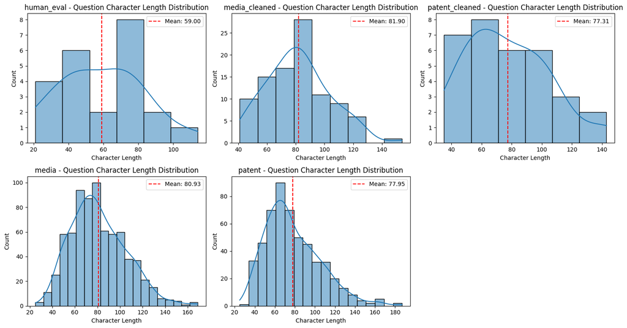

```python
import seaborn as sns
import matplotlib.pyplot as plt

def plot_question_length_distribution(df, label, ax):
    lengths = df["question"].map(len)
    mean_len = lengths.mean()

    sns.histplot(lengths, kde=True, ax=ax)
    ax.set_title(f"{label} - Question Character Length Distribution")
    ax.set_xlabel("Character Length")
    ax.set_ylabel("Count")
    ax.axvline(mean_len, color='r', linestyle='--', label=f"Mean: {mean_len:.2f}")
    ax.legend()

# Access like:
# Setup subplots
fig, axes = plt.subplots(2, 3, figsize=(15, 8))
axes = axes.flatten()  # To index as a 1D array

# Plot each DataFrame
for idx, (name, df) in enumerate(human_eval_dfs.items()):
    plot_question_length_distribution(df, name, axes[idx])

# Hide unused subplots (if any)
for j in range(len(human_eval_dfs), len(axes)):
    fig.delaxes(axes[j])

plt.tight_layout()
plt.show()
```

Our exploration has identified instances where articles linked to specific questions appear to be missing from the dataset. To determine the root cause, let's investigate whether these articles are genuinely absent or if inconsistencies in URL formatting are creating the illusion of missing data. Normalizing the URLs across the dataset will help us differentiate between these two scenarios.

```python
def normalize_url(url: str) -> str:
    url = url.replace("https://", "")
    url = url.replace("http://", "")
    url = url.replace("www.", "")
    url = url.rstrip("/")
    return url


for name, df in human_eval_dfs.items():

  print(name)
  if "patent" in name:
    df.rename(columns={"relevant_text":"relevant_section","context":"relevant_section"}, inplace=True)
    human_eval_dfs[name]=df
    continue


  missing_articles = df.copy()
  missing_articles = missing_articles[~df["url"].isin(articles_df["url"])]
  missing_articles

  articles_df["url"] = articles_df["url"].map(normalize_url)
  df["url"] = df["url"].map(normalize_url)

  missing_articles = df.copy()
  missing_articles = missing_articles[~df["url"].isin(articles_df["url"])]
  missing_articles

  # We also know from previous analysis that some duplicate articles from the "energyvoice" domain so we will also normalize these URLs.
  missing_articles["url"] = missing_articles["url"].map(lambda x: x.replace("sgvoice.net", "sgvoice.energyvoice.com"))

  missing_articles[~missing_articles["url"].isin(articles_df["url"])]

  # df.loc[missing_articles.index, "url"] = missing_articles["url"]
  # df[df["url"].isin(articles_df["url"])]
  df.loc[missing_articles.index, "url"] = missing_articles["url"]
  df[df["url"].isin(articles_df["url"])]




  human_eval_dfs[name]=df
  display(df.head())
```

```
human_eval
```

|  | example_id | question | relevant_text | answer | url |
| --- | --- | --- | --- | --- | --- |
| 0 | 1 | What is the innovation behind Leclanché's new ... | Leclanché said it has developed an environment... | Leclanché's innovation is using a water-based ... | sgvoice.energyvoice.com/strategy/technology/23... |
| 1 | 2 | What is the EU’s Green Deal Industrial Plan? | The Green Deal Industrial Plan is a bid by the... | The EU’s Green Deal Industrial Plan aims to en... | sgvoice.energyvoice.com/policy/25396/eu-seeks-... |
| 2 | 3 | What is the EU’s Green Deal Industrial Plan? | The European counterpart to the US Inflation R... | The EU’s Green Deal Industrial Plan aims to en... | pv-magazine.com/2023/02/02/european-commission... |
| 3 | 4 | What are the four focus areas of the EU's Gree... | The new plan is fundamentally focused on four ... | The four focus areas of the EU's Green Deal In... | sgvoice.energyvoice.com/policy/25396/eu-seeks-... |
| 4 | 5 | When did the cooperation between GM and Honda ... | What caught our eye was a new hookup between G... | July 2013 | cleantechnica.com/2023/05/08/general-motors-se... |

```
media_cleaned
```

|  | id | relevant_section | question | answer | url | category | groundedness_score | groundedness_eval | relevance_score | relevance_eval | standalone_score | standalone_eval |
| --- | --- | --- | --- | --- | --- | --- | --- | --- | --- | --- | --- | --- |
| 0 | 0 | As we move toward a sustainable future, green ... | What is green hydrogen, and how is it produced? | Green hydrogen is a sustainable energy carrier... | azocleantech.com/article.aspx?ArticleID=1823 | Sustainability & Technological Innovation Ques... | 5.0 | The provided context clearly explains what gre... | 3.0 | The question is straightforward and clear, inq... | 5.0 | The question is self-explanatory and does not ... |
| 1 | 5 | As we move toward a sustainable future, green ... | What is the significance of the Neom project i... | The Neom project, a partnership between ACWA P... | azocleantech.com/article.aspx?ArticleID=1823 | Sustainability & Technological Innovation Ques... | 5.0 | The context provides a comprehensive overview ... | 4.0 | The Neom project is a key concept in the conte... | 4.0 | The question appears to rely on additional kno... |
| 2 | 8 | As we move toward a sustainable future, green ... | What is the significance of the Energy Transit... | The report highlights the need for a 30-year t... | azocleantech.com/article.aspx?ArticleID=1823 | Sustainability & Technological Innovation Ques... | 5.0 | The question regarding the significance of the... | 3.0 | This question appears to be relevant to enviro... | 5.0 | The question refers to a specific institution ... |
| 3 | 10 | As we move toward a sustainable future, green ... | How does green hydrogen compare to direct use ... | Green hydrogen production through electrolysis... | azocleantech.com/article.aspx?ArticleID=1823 | Sustainability & Technological Innovation Ques... | 4.0 | The question requires an in-depth analysis of ... | 4.0 | This question is relevant to NLP developers bu... | 5.0 | The question implies that there might be some ... |
| 4 | 14 | As we move toward a sustainable future, green ... | What are some of the examples of pilot project... | Various pilot projects are testing green hydro... | azocleantech.com/article.aspx?ArticleID=1823 | Sustainability & Technological Innovation Ques... | 5.0 | The question can be answered unambiguously bas... | 3.0 | This question appears to be focused on environ... | 4.0 | The question asks for specific examples of pil... |

```
patent_cleaned
media
```

|  | id | question | relevant_text | answer | url | category |
| --- | --- | --- | --- | --- | --- | --- |
| 0 | 0 | What is green hydrogen, and how is it produced? | As we move toward a sustainable future, green ... | Green hydrogen is a sustainable energy carrier... | azocleantech.com/article.aspx?ArticleID=1823 | Sustainability & Technological Innovation Ques... |
| 1 | 1 | Who are some of the key players involved in th... | As we move toward a sustainable future, green ... | Key players include companies like Siemens Ene... | azocleantech.com/article.aspx?ArticleID=1823 | Sustainability & Technological Innovation Ques... |
| 2 | 2 | What are the main challenges associated with i... | As we move toward a sustainable future, green ... | The main challenges include technical hurdles ... | azocleantech.com/article.aspx?ArticleID=1823 | Sustainability & Technological Innovation Ques... |
| 3 | 3 | What is the role of the European Union's Hydro... | As we move toward a sustainable future, green ... | The strategy aims to significantly ramp up gre... | azocleantech.com/article.aspx?ArticleID=1823 | Sustainability & Technological Innovation Ques... |
| 4 | 4 | How does the Hydrogen Council facilitate partn... | As we move toward a sustainable future, green ... | The Hydrogen Council brings together over 80 e... | azocleantech.com/article.aspx?ArticleID=1823 | Government & Corporate Initiatives |

```
patent
```

In the end we are able to find all the articles that are linked to the evaluation data and have therefore successfully completed our exploratory data analysis and preprocessing.

## Subsampling

For faster processing and to reduce the cost of running the notebook we will subsample the dataset to 1000 articles. This will allow us to run the notebook in a reasonable amount of time and still provide meaningful results. Because the distribution of articles across publishers is skewed we will use stratified sampling to ensure that we have a representative sample. We also need to keep in mind that the evaluation data are linked to specific articles so we need to make sure that these are included in the subsample.

```python
def do_stratification(
        df: pd.DataFrame,
        column: str,
        sample_size: int,
        seed: int = 42
) -> pd.DataFrame:
    res_df = df.copy()
    indx = df.groupby(column, group_keys=False)[column].apply(lambda x: x.sample(n=int(sample_size/len(df) * len(x)), random_state=seed)).index.to_list()
    return res_df.loc[indx]
```

```python
for name, df in human_eval_dfs.items():
  print(name)
```

```
human_eval
media_cleaned
patent_cleaned
media
patent
```

```python
sample_dfs = {}

for name, df in human_eval_dfs.items():
  if "patent" in name:
    if name =="patent":
      eval_abstracts_df_patent = patents_df[
      patents_df["title"].str.lower().isin(df["title"].str.lower()) |
      patents_df["abstract"].str.lower().isin(df["relevant_section"].str.lower())
      ]
    else:
      eval_abstracts_df_patent = patents_df[patents_df["abstract"].str.lower().isin(df["relevant_section"].str.lower())]

    eval_abstracts_df_patent.head()

    sample_df = do_stratification(patents_df, "topic", 1000, 69)
    # if the articles are already in the subsample from the evaluation set, then we remove them, so we just want unique urls
    sample_df = sample_df[~sample_df["title"].isin(eval_abstracts_df_patent["title"]) & ~sample_df["abstract"].isin(eval_abstracts_df_patent["abstract"])]
    sample_df = pd.concat([sample_df, eval_abstracts_df_patent])
    sample_df.info()

  else:
    eval_df = articles_df[articles_df["url"].isin(df["url"])]
    eval_df.head()

    sample_df = do_stratification(articles_df, "domain", 1000, 69)
    # if the articles are already in the subsample from the evaluation set, then we remove them, so we just want unique urls
    sample_df = sample_df[~sample_df["url"].isin(eval_df["url"])]
    sample_df = pd.concat([sample_df, eval_df])
    sample_df.info()

  sample_dfs[f'sample_df_{name}']=sample_df
  display(sample_df.head())
```

```
<class 'pandas.core.frame.DataFrame'>
Index: 1026 entries, Charging Ahead: The UK’ s Electric Vehicle Revolution to Scout, Colgate-Palmolive Sign PPA for Texas Solar Farm
Data columns (total 6 columns):
 #   Column       Non-Null Count  Dtype
---  ------       --------------  -----
 0   content      1026 non-null   object
 1   domain       1026 non-null   object
 2   url          1026 non-null   object
 3   article      1026 non-null   object
 4   lang         1026 non-null   object
 5   readability  1026 non-null   float64
dtypes: float64(1), object(5)
memory usage: 56.1+ KB
```

| title | content | domain | url | article | lang | readability |
| --- | --- | --- | --- | --- | --- | --- |
| Charging Ahead: The UK’ s Electric Vehicle Revolution | ["Change is sweeping the highways of the Unite... | all-energy | forum.all-energy.co.uk/2024/01/26/charging-ahe... | Change is sweeping the highways of the United ... | en | 40.69 |
| Moose can be Responsible for Huge Amounts of Carbon Emissions from Forests | ["By clicking `` Allow All '' you agree to the... | azocleantech | azocleantech.com/news.aspx?newsID=33043 | One of the biggest potential single sources o... | en | 51.07 |
| ABS Alaskan, Inc.: Quotes, Address, Contact | ["By clicking `` Allow All '' you agree to the... | azocleantech | azocleantech.com/suppliers.aspx?SupplierID=1121 | ABS Alaskan are a manufacturer and supplier o... | en | 28.94 |
| Renewables Project Delivers Green Energy for the Green Screen | ['We use cookies to enhance your experience. B... | azocleantech | azocleantech.com/news.aspx?NewsID=33950 | We use cookies to enhance your experience. By ... | en | 44.54 |
| The Cleantech Report by Lux Research | ["By clicking `` Allow All '' you agree to the... | azocleantech | azocleantech.com/reports-and-docs-details.aspx... | Introducing the authoritative guide to emergi... | en | 23.46 |

```
<class 'pandas.core.frame.DataFrame'>
Index: 1045 entries, Charging Ahead: The UK’ s Electric Vehicle Revolution to Multi-Junction Solar Cells Offer a New Path to Sustainable Energy
Data columns (total 6 columns):
 #   Column       Non-Null Count  Dtype
---  ------       --------------  -----
 0   content      1045 non-null   object
 1   domain       1045 non-null   object
 2   url          1045 non-null   object
 3   article      1045 non-null   object
 4   lang         1045 non-null   object
 5   readability  1045 non-null   float64
dtypes: float64(1), object(5)
memory usage: 57.1+ KB
```

| title | content | domain | url | article | lang | readability |
| --- | --- | --- | --- | --- | --- | --- |
| Charging Ahead: The UK’ s Electric Vehicle Revolution | ["Change is sweeping the highways of the Unite... | all-energy | forum.all-energy.co.uk/2024/01/26/charging-ahe... | Change is sweeping the highways of the United ... | en | 40.69 |
| Moose can be Responsible for Huge Amounts of Carbon Emissions from Forests | ["By clicking `` Allow All '' you agree to the... | azocleantech | azocleantech.com/news.aspx?newsID=33043 | One of the biggest potential single sources o... | en | 51.07 |
| ABS Alaskan, Inc.: Quotes, Address, Contact | ["By clicking `` Allow All '' you agree to the... | azocleantech | azocleantech.com/suppliers.aspx?SupplierID=1121 | ABS Alaskan are a manufacturer and supplier o... | en | 28.94 |
| Renewables Project Delivers Green Energy for the Green Screen | ['We use cookies to enhance your experience. B... | azocleantech | azocleantech.com/news.aspx?NewsID=33950 | We use cookies to enhance your experience. By ... | en | 44.54 |
| The Cleantech Report by Lux Research | ["By clicking `` Allow All '' you agree to the... | azocleantech | azocleantech.com/reports-and-docs-details.aspx... | Introducing the authoritative guide to emergi... | en | 23.46 |

```
<class 'pandas.core.frame.DataFrame'>
Index: 1009 entries, CN-215498834-U to CN-112737031-B
Data columns (total 10 columns):
 #   Column              Non-Null Count  Dtype
---  ------              --------------  -----
 0   application_number  1009 non-null   object
 1   country_code        1009 non-null   object
 2   title               1009 non-null   object
 3   abstract            1009 non-null   object
 4   title_lang          1009 non-null   object
 5   abstract_lang       1009 non-null   object
 6   text                1009 non-null   object
 7   cleaned_text        1009 non-null   object
 8   topic               1009 non-null   int64
 9   readability         1009 non-null   float64
dtypes: float64(1), int64(1), object(8)
memory usage: 86.7+ KB
```

| publication_number | application_number | country_code | title | abstract | title_lang | abstract_lang | text | cleaned_text | topic | readability |
| --- | --- | --- | --- | --- | --- | --- | --- | --- | --- | --- |
| CN-215498834-U | CN-202121886754-U | CN | Light condensing device for photovoltaic module | The utility model discloses a light condensing... | en | en | Light condensing device for photovoltaic modul... | light condensing device photovoltaic module ut... | 0 | -27.66 |
| CN-216010674-U | CN-202122187726-U | CN | Light-following solar street lamp | The utility model discloses a formula of follo... | en | en | Light-following solar street lamp. The utility... | light-following solar street lamp utility mode... | 0 | -11.93 |
| CN-217273867-U | CN-202220415854-U | CN | City and road lighting engineering are with as... | The utility model relates to a street lamp tec... | en | en | City and road lighting engineering are with as... | city road lighting engineering assembling stre... | 0 | -25.47 |
| CN-114978010-A | CN-202210806247-A | CN | Solar energy storage device with adjustable an... | The invention discloses a solar energy storage... | en | en | Solar energy storage device with adjustable an... | solar energy storage device adjustable angle l... | 0 | -6.86 |
| CN-219107378-U | CN-202223472295-U | CN | Support hook for fixing solar panel and fixing... | The application relates to the technical field... | en | en | Support hook for fixing solar panel and fixing... | support hook fixing solar panel fixing frame u... | 0 | 19.07 |

```
<class 'pandas.core.frame.DataFrame'>
Index: 1056 entries, Charging Ahead: The UK’ s Electric Vehicle Revolution to Multi-Junction Solar Cells Offer a New Path to Sustainable Energy
Data columns (total 6 columns):
 #   Column       Non-Null Count  Dtype
---  ------       --------------  -----
 0   content      1056 non-null   object
 1   domain       1056 non-null   object
 2   url          1056 non-null   object
 3   article      1056 non-null   object
 4   lang         1056 non-null   object
 5   readability  1056 non-null   float64
dtypes: float64(1), object(5)
memory usage: 57.8+ KB
```

| title | content | domain | url | article | lang | readability |
| --- | --- | --- | --- | --- | --- | --- |
| Charging Ahead: The UK’ s Electric Vehicle Revolution | ["Change is sweeping the highways of the Unite... | all-energy | forum.all-energy.co.uk/2024/01/26/charging-ahe... | Change is sweeping the highways of the United ... | en | 40.69 |
| Moose can be Responsible for Huge Amounts of Carbon Emissions from Forests | ["By clicking `` Allow All '' you agree to the... | azocleantech | azocleantech.com/news.aspx?newsID=33043 | One of the biggest potential single sources o... | en | 51.07 |
| ABS Alaskan, Inc.: Quotes, Address, Contact | ["By clicking `` Allow All '' you agree to the... | azocleantech | azocleantech.com/suppliers.aspx?SupplierID=1121 | ABS Alaskan are a manufacturer and supplier o... | en | 28.94 |
| Renewables Project Delivers Green Energy for the Green Screen | ['We use cookies to enhance your experience. B... | azocleantech | azocleantech.com/news.aspx?NewsID=33950 | We use cookies to enhance your experience. By ... | en | 44.54 |
| The Cleantech Report by Lux Research | ["By clicking `` Allow All '' you agree to the... | azocleantech | azocleantech.com/reports-and-docs-details.aspx... | Introducing the authoritative guide to emergi... | en | 23.46 |

```
<class 'pandas.core.frame.DataFrame'>
Index: 1023 entries, CN-215498834-U to CN-113903531-A
Data columns (total 10 columns):
 #   Column              Non-Null Count  Dtype
---  ------              --------------  -----
 0   application_number  1023 non-null   object
 1   country_code        1023 non-null   object
 2   title               1023 non-null   object
 3   abstract            1023 non-null   object
 4   title_lang          1023 non-null   object
 5   abstract_lang       1023 non-null   object
 6   text                1023 non-null   object
 7   cleaned_text        1023 non-null   object
 8   topic               1023 non-null   int64
 9   readability         1023 non-null   float64
dtypes: float64(1), int64(1), object(8)
memory usage: 87.9+ KB
```

| publication_number | application_number | country_code | title | abstract | title_lang | abstract_lang | text | cleaned_text | topic | readability |
| --- | --- | --- | --- | --- | --- | --- | --- | --- | --- | --- |
| CN-215498834-U | CN-202121886754-U | CN | Light condensing device for photovoltaic module | The utility model discloses a light condensing... | en | en | Light condensing device for photovoltaic modul... | light condensing device photovoltaic module ut... | 0 | -27.66 |
| CN-216010674-U | CN-202122187726-U | CN | Light-following solar street lamp | The utility model discloses a formula of follo... | en | en | Light-following solar street lamp. The utility... | light-following solar street lamp utility mode... | 0 | -11.93 |
| CN-217273867-U | CN-202220415854-U | CN | City and road lighting engineering are with as... | The utility model relates to a street lamp tec... | en | en | City and road lighting engineering are with as... | city road lighting engineering assembling stre... | 0 | -25.47 |
| CN-114978010-A | CN-202210806247-A | CN | Solar energy storage device with adjustable an... | The invention discloses a solar energy storage... | en | en | Solar energy storage device with adjustable an... | solar energy storage device adjustable angle l... | 0 | -6.86 |
| CN-219107378-U | CN-202223472295-U | CN | Support hook for fixing solar panel and fixing... | The application relates to the technical field... | en | en | Support hook for fixing solar panel and fixing... | support hook fixing solar panel fixing frame u... | 0 | 19.07 |

Now all is prepared to start developing our RAG!

# Chunking

Chunking is a crucial step in the RAG pipeline. It involves breaking down the articles into smaller, more manageable pieces.

[figure not shown]

There are mainly two reasons for this:

- **Generation:** The LLM has a limit on the number of tokens it can process at once. By chunking the articles, we can ensure that the LLM can generate responses without running into this limit. Another reason to use chunks for the generation step is to avoid "distractions" from irrelevant parts of the article. Just like if you were given a book and asked to answer a question about a the book it would be easier if you were just given the relevant chapter.
- **Retrieval:** Just like the LLM, the embedding model in the retrieval step has a limit on the number of tokens it can process at once. By chunking the articles, we can ensure that the embedding model can process the entire article. By chunking the articles, we can also improve the retrieval performance by having fine-grained chunks that can be matched more closely to the user query, rather then more general chunks.

### Creating the Chunks

In this notebook we will be using two different chunking strategies:

- **Recursive Chunking:** This strategy involves recursively splitting the article into smaller chunks based on the article structure such as paragraphs and sentences until the chunk size is less than or equal to the maximum chunk size.
- **Semantic Chunking:** This strategy involves splitting the article into chunks based on semantic boundaries. This strategy finds boundaries between sentences that are semantically different and splits the article at these boundaries to create chunks. To do this we will need to use an embedding model to calculate the similarity between sentences. These embedding models will then also be used in the retrieval step to find the most relevant chunks.

To see how different texts get chunked with different strategies and chunk sizes check out the [Chunking Visualizer](https://chunkviz.up.railway.app/).

```python
def get_recursive_splitter(chunk_size: int, chunk_overlap: int) -> TextSplitter:
    return RecursiveCharacterTextSplitter(
        chunk_size=chunk_size,
        chunk_overlap=chunk_overlap,
        separators=["\n\n", "\n", "(?<=\. )", " ", ""],
        length_function=len,
    )
```

### we thought of implementing one more splitter

but instead of splitting in characters we implement a function to split in tokens

```python
from transformers import AutoTokenizer
```

```python
def get_recursive_splitter_on_token(chunk_size: int, chunk_overlap: int, tokenizer_name: str) -> TextSplitter:
  return RecursiveCharacterTextSplitter.from_huggingface_tokenizer(
        AutoTokenizer.from_pretrained(tokenizer_name),
        chunk_size=chunk_size,
        chunk_overlap=int(chunk_size / 5),
        add_start_index=True,
        strip_whitespace=True,
        separators=["\n\n", "\n", "(?<=\. )", " ", ""],
    )
```

Let us set the device for efficient use of available resources.

```python
# if we can make use of any device that is better than the CPU, we will use it
device = "cpu"
if torch.cuda.is_available():
    device = "cuda"
elif torch.backends.mps.is_available():
    device = "mps"

model_kwargs = {'device': device, "trust_remote_code": True}
model_kwargs
```

```
{'device': 'cpu', 'trust_remote_code': True}
```

We select four embedding models from HuggingFace to represent our text fragments in numerical forma in a vector space.

#### We thought a effective improvement would be to use approapiate embeddings

We discuss 2 approaches a Domain-adapted variant (PatentSBERT) or fine-tuned “all-mpnet-base-v2” If a model specifically pre-trained on patent or technical texts is available (for instance, a variant sometimes referred to as PatentSBERT), this could further improve performance on technical documents. Alternatively, you can take all-mpnet-base-v2 and fine-tune it on your cleantech patent and media datasets to create a bespoke embedding model that better captures the domain’s specialized vocabulary and nuances.

```python
embedding_models = {
    "mini": HuggingFaceEmbeddings(model_name="sentence-transformers/all-mpnet-base-v2", model_kwargs=model_kwargs),
    "bge-m3": HuggingFaceEmbeddings(model_name="BAAI/bge-m3", model_kwargs=model_kwargs),
    "gte": HuggingFaceEmbeddings(model_name="Alibaba-NLP/gte-base-en-v1.5", model_kwargs=model_kwargs),
    "PatentSBERTa": HuggingFaceEmbeddings(model_name="AI-Growth-Lab/PatentSBERTa", model_kwargs=model_kwargs)
}
```

[output not shown]

```
A new version of the following files was downloaded from https://huggingface.co/Alibaba-NLP/new-impl:
- configuration.py
. Make sure to double-check they do not contain any added malicious code. To avoid downloading new versions of the code file, you can pin a revision.
```

```
A new version of the following files was downloaded from https://huggingface.co/Alibaba-NLP/new-impl:
- modeling.py
. Make sure to double-check they do not contain any added malicious code. To avoid downloading new versions of the code file, you can pin a revision.
```

We also define the chunking strategies to be used. The recursive splittering is characterized by the length of chunks and the overlap between adjacent chunks. For the semantic chunking, sentences embedded as dense vectors are merged as long as the cosine distance between two consecutive sentences does not exceed a percentile based threshold.

```python
# introduce more variants

recursive_256_token_splitter_mini_emb = get_recursive_splitter_on_token(256,64, "sentence-transformers/all-mpnet-base-v2")
recursive_1024_token_splitter_mini_emb = get_recursive_splitter_on_token(1024,128, "sentence-transformers/all-mpnet-base-v2")

recursive_256_token_splitter_patent_emb = get_recursive_splitter_on_token(256,64, "AI-Growth-Lab/PatentSBERTa")
recursive_1024_token_splitter_patent_emb = get_recursive_splitter_on_token(1024,128, "AI-Growth-Lab/PatentSBERTa")

recursive_256_splitter = get_recursive_splitter(256, 64)
recursive_1024_splitter = get_recursive_splitter(1024, 128)

semantic_splitter = SemanticChunker(
    embedding_models["gte"], breakpoint_threshold_type="percentile"
)

splitters = {
    "recursive_256": recursive_256_splitter,
    "recursive_1024": recursive_1024_splitter,
    "semantic": semantic_splitter,
    "recursive_token_256_mini_emb":recursive_256_token_splitter_mini_emb,
    "recursive_token_1024_mini_emb":recursive_1024_token_splitter_mini_emb,
    "recursive_token_256_patent_emb":recursive_256_token_splitter_patent_emb,
    "recursive_token_1024_patent_emb":recursive_1024_token_splitter_patent_emb,
}
```

```python
from typing import Dict, List, Tuple

def chunk_documents(df: pd.DataFrame, text_splitter) -> Tuple[List[Document],]:
    chunks = []
    id = 0

    for _, row in tqdm(df.iterrows(), total=len(df)):
        # Determine which text fields to use
        if 'article' in df.columns:
            content = row['article']
            title = row.get('title', '')
            full_text = f"{title}: {content}"
            metadata = {
                'title': title,
                'url': row.get('url', ''),
                'domain': row.get('domain', ''),
            }
        elif 'abstract' in df.columns:
            content = row['abstract']
            title = row.get('title', '')
            full_text = f"{title}: {content}"
            metadata = {
                'title': title,
                'topic': row.get('topic', ''),
            }
        else:
            continue  # Skip rows that don't have expected fields

        char_chunks = text_splitter.split_text(full_text)
        for chunk in char_chunks:
            id += 1
            chunk_metadata = metadata.copy()
            chunk_metadata['id'] = id
            chunks.append(Document(
                page_content=chunk,
                metadata=chunk_metadata,
            ))

    return chunks
```

```python
chunks_folder = silver_folder / "chunks"
if not chunks_folder.exists():
    chunks_folder.mkdir()
```

The following function will load existing chunks, prepared for our tutorial to speed up the preparation process.

```python
def get_or_create_chunks(df: pd.DataFrame, text_splitter: TextSplitter, splitter_name: str) -> List[Document]:
    chunks_file = chunks_folder / f"{splitter_name}_chunks.json"

    if chunks_file.exists():
        with open(chunks_file, "r") as file:
            chunks = [Document(**chunk) for chunk in json.load(file)]
        print(f"Loaded {len(chunks)} chunks from {chunks_file}")
    else:
        chunks = chunk_documents(df, text_splitter)
        with open(chunks_file, "w") as file:
            json.dump([doc.dict() for doc in chunks], file, indent=4)
        print(f"Saved {len(chunks)} chunks to {chunks_file}")
    return chunks
```

```python
chunks = {}
for splitter_name, splitter in splitters.items():
    for name, df in sample_dfs.items():

        # Create chunks based on the total sample dataframe, not the cleaned datasets.
        # Since the cleaned datasets are subsets of the total dataset, chunking them separately would be redundant.
        if "cleaned" in name:
          continue
        split_type = name.replace('sample_df','').replace('_human_eval','')
        print(f"{splitter_name}{split_type}")
        chunks[f"{splitter_name}{split_type}"] = get_or_create_chunks(df, splitter, splitter_name+split_type)
```

```
recursive_256
Loaded 26630 chunks from data/silver/chunks/recursive_256_chunks.json
recursive_256_media
Loaded 27820 chunks from data/silver/chunks/recursive_256_media_chunks.json
recursive_256_patent
Loaded 6777 chunks from data/silver/chunks/recursive_256_patent_chunks.json
recursive_1024
Loaded 6018 chunks from data/silver/chunks/recursive_1024_chunks.json
recursive_1024_media
Loaded 6288 chunks from data/silver/chunks/recursive_1024_media_chunks.json
recursive_1024_patent
Loaded 1825 chunks from data/silver/chunks/recursive_1024_patent_chunks.json
semantic
Loaded 3298 chunks from data/silver/chunks/semantic_chunks.json
semantic_media
Loaded 3457 chunks from data/silver/chunks/semantic_media_chunks.json
semantic_patent
Loaded 1313 chunks from data/silver/chunks/semantic_patent_chunks.json
recursive_token_256_mini_emb
Loaded 4885 chunks from data/silver/chunks/recursive_token_256_mini_emb_chunks.json
recursive_token_256_mini_emb_media
Loaded 5521 chunks from data/silver/chunks/recursive_token_256_mini_emb_media_chunks.json
recursive_token_256_mini_emb_patent
Loaded 1807 chunks from data/silver/chunks/recursive_token_256_mini_emb_patent_chunks.json
recursive_token_1024_mini_emb
Loaded 1513 chunks from data/silver/chunks/recursive_token_1024_mini_emb_chunks.json
recursive_token_1024_mini_emb_media
Loaded 1603 chunks from data/silver/chunks/recursive_token_1024_mini_emb_media_chunks.json
recursive_token_1024_mini_emb_patent
Loaded 1336 chunks from data/silver/chunks/recursive_token_1024_mini_emb_patent_chunks.json
recursive_token_256_patent_emb
Loaded 4885 chunks from data/silver/chunks/recursive_token_256_patent_emb_chunks.json
recursive_token_256_patent_emb_media
Loaded 5521 chunks from data/silver/chunks/recursive_token_256_patent_emb_media_chunks.json
recursive_token_256_patent_emb_patent
Loaded 1807 chunks from data/silver/chunks/recursive_token_256_patent_emb_patent_chunks.json
recursive_token_1024_patent_emb
Loaded 1513 chunks from data/silver/chunks/recursive_token_1024_patent_emb_chunks.json
recursive_token_1024_patent_emb_media
Loaded 1603 chunks from data/silver/chunks/recursive_token_1024_patent_emb_media_chunks.json
recursive_token_1024_patent_emb_patent
Loaded 1336 chunks from data/silver/chunks/recursive_token_1024_patent_emb_patent_chunks.json
```

Now that we have created and saved the chunks we can analyze them. We can already see above that the semantic chunks are generally larger than the recursive chunks.

## Generating Embeddings

Now that we have clean chunks, the next step involves generating embeddings for our article chunks. These embeddings will serve as a crucial component for efficient retrieval within the RAG pipeline. For our vector store we'll utilize ChromaDB, a powerful tool for indexing and searching high-dimensional data. To integrate our chosen embedding models with ChromaDB, we'll define a custom wrapper class. This wrapper class will act as an intermediary, ensuring seamless communication between the models and the ChromaDB indexing system.

```python
class CustomChromadbEmbeddingFunction(EmbeddingFunction):

    def __init__(self, model) -> None:
        super().__init__()
        self.model = model

    def _embed(self, l):
        return [self.model.embed_query(x) for x in l]

    def embed_query(self, query):
        return self._embed([query])

    def __call__(self, input: Documents) -> Embeddings:
        embeddings = self._embed(input)
        return embeddings
```

We prepare three different embedding models in this tutorial.

Here we only use the best embedding models in the base line( which was BGE-M3 and GTE ) along our suggested embedding model

```python
chroma_embedding_functions = {
    "bge-m3": CustomChromadbEmbeddingFunction(embedding_models["bge-m3"]),
    "gte": CustomChromadbEmbeddingFunction(embedding_models["gte"]),
    "PatentSBERTa":CustomChromadbEmbeddingFunction(embedding_models["PatentSBERTa"])
}
for name, embedding_function in chroma_embedding_functions.items():
    sample = embedding_function(["Hello, world!"])[0][:5]
    print(f"{name} embedding sample: {sample}")
```

```
bge-m3 embedding sample: [-0.016155675053596497, 0.026993436738848686, -0.04258321225643158, 0.013542227447032928, -0.01935460790991783]
gte embedding sample: [0.03789430856704712, 0.3469233214855194, -0.20471355319023132, -0.2123861461877823, -0.4910067021846771]
PatentSBERTa embedding sample: [0.22980061173439026, -0.24824954569339752, -0.2995477020740509, -0.08181057870388031, 0.36161354184150696]
```

Generating embeddings can be a computationally intensive process. To optimize efficiency and avoid redundant computations, we'll leverage checkpointing. This technique involves storing the generated embeddings along with their corresponding article chunks. We'll define a simple class to encapsulate this data, facilitating efficient retrieval and reducing the need for recalculating embeddings unless absolutely necessary.

```python
embeddings_folder = silver_folder / "embeddings"
if not embeddings_folder.exists():
    embeddings_folder.mkdir()
```

```python
class DocumentEmbedding():
    def __init__(self, document: Document, text_embedding: List[float]) -> None:
        self.document = document
        self.text_embedding = text_embedding

    def to_dict(self) -> Dict:
        return {
            "document": self.document.dict(),
            "text_embedding": self.text_embedding
        }

    @classmethod
    def from_dict(cls, d: Dict) -> "DocumentEmbedding":
        return cls(
            document=Document(**d["document"]),
            text_embedding=d["text_embedding"]
        )


def get_or_create_embeddings(
        embedding_function: EmbeddingFunction,
        chunks: List[Document],
        embedding_name: str,
) -> List[DocumentEmbedding]:
    embeddings_file = embeddings_folder / f"{embedding_name}_embeddings.json"
    if embeddings_file.exists():
        with open(embeddings_file, "r") as file:
            embeddings = [DocumentEmbedding.from_dict(embedding) for embedding in json.load(file)]
        print(f"Loaded {len(embeddings)} embeddings from {embeddings_file}")
    else:
        embeddings = []
        for chunk in tqdm(chunks):
            text_embedding = embedding_function([chunk.page_content])[0]
            embedding = DocumentEmbedding(
                document=chunk,
                text_embedding=text_embedding
            )
            embeddings.append(embedding)
        with open(embeddings_file, "w") as file:
            json.dump([embedding.to_dict() for embedding in embeddings], file, indent=4)
        print(f"Saved {len(embeddings)} embeddings to {embeddings_file}")
    return embeddings
```

```python
embeddings = {}
for embedding_name, embedding_function in chroma_embedding_functions.items():
    for splitter_name, splitter_chunks in chunks.items():
        if f"{embedding_name}_{splitter_name}" in selected_embeddings:
          print(f"Generating embeddings for {embedding_name} with {splitter_name} splitter")
          embeddings[f"{embedding_name}_{splitter_name}"] = get_or_create_embeddings(
              embedding_function, splitter_chunks, f"{embedding_name}_{splitter_name}"
          )
```

[output not shown]

The number of embeddings relates to the number of chunks produced by the individual chunking strategies, not the embedding dimensions. Thus smaller chunk size (e.g. 256) yields more chunks than larger chunk size (1024), and semantic embeddings even less chunks.

## Storing the Embeddings in ChromaDB

As mentioned above for our semantic search retrieval we will be storing the embeddings in ChromaDB. ChromaDB is a powerful tool for indexing and searching high-dimensional data. It is allows e.g. to use approximate nearest neighbor (ANN) search based on the Hierarchical Navigable Small World (HNSW) algorithm, which is known for its efficiency in searching high-dimensional spaces.

Just like with normal SQL databases we have a server, in this case an SQLite server, that we can connect to with a client. We will then use the client to connect to the server and create for each set of embeddings a new seperate database which can be thought of as the index or a vector space. ChromaDB calls these separate vector spaces "collections". These collections will then be used to search for the most relevant chunks to a user query.

[figure not shown]

```python
gold_folder = data_folder / "gold"
if not gold_folder.exists():
    gold_folder.mkdir()
chromadb_folder = gold_folder / "chromadb"
if not chromadb_folder.exists():
    chromadb_folder.mkdir()

chroma_client = chromadb.PersistentClient(path=chromadb_folder.as_posix())
```

Again we can make use of preprocessed data as before to speed up the preparatory steps.

```python
def get_or_create_collection(
        name: str,
        embedding_function: EmbeddingFunction,
        embeddings: List[DocumentEmbedding],
        batch_size: int = 128
) -> Collection:

    collection = chroma_client.get_or_create_collection(
        name=name,
        # configure to use cosine distance not default L2
        metadata={"hnsw:space": "cosine"},
        embedding_function=embedding_function
    )

    if collection.count() == 0:
        for i in tqdm(range(0, len(embeddings), batch_size)):
            batch = embeddings[i:i+batch_size]
            collection.add(
                documents=[embedding.document.page_content for embedding in batch],
                embeddings=[embedding.text_embedding for embedding in batch],
                ids=[str(embedding.document.metadata["id"]) for embedding in batch],
                metadatas=[embedding.document.metadata for embedding in batch]
            )

    return collection
```

```python
collections = {}
for collection_name, current_embeddings in embeddings.items():
    collection = get_or_create_collection(
        collection_name,
        chroma_embedding_functions[collection_name.split("_")[0]],
        current_embeddings
    )
    collections[collection_name] = collection
    print(f"Collection {collection_name} has {collection.count()} documents")
```

[output not shown]

Once we have stored all the embeddings in ChromaDB we can test the retrieval process by querying one of our collections and see what the most similar chunks are. Try some different queries and see what the most similar chunks are and whether they make sense.

```python
collections.keys()
```

```
dict_keys(['gte_recursive_1024_patent'])
```

```python
def wrap_text(text: str, char_per_line=100) -> str:
    # for better readability, wrap the text at the last space before the char_per_line
    if len(text) < char_per_line:
        return text
    else:
        return text[:char_per_line].rsplit(' ', 1)[0] + '\n' + wrap_text(text[len(text[:char_per_line].rsplit(' ', 1)[0])+1:], char_per_line)
```

```python
selected_collection = collections["gte_recursive_1024"]
results = selected_collection.query(
    query_texts=["Climate Change"],
    n_results=3,
)
for doc in results["documents"][0]:
    print(wrap_text(doc))
    print()
```

[output not shown]

### Implement the Hybrid Retrieval

```python
!pip install rank_bm25
import nltk
nltk.download('punkt')
nltk.download('punkt_tab')
nltk.download('averaged_perceptron_tagger')
from nltk.tokenize import word_tokenize
from rank_bm25 import BM25Okapi
```

## Hybrid Search (Sparse + Dense Retrieval)

Hybrid retrieval combines **sparse retrieval** (term-based search like BM25) with **dense retrieval** (embedding-based similarity). In a RAG pipeline, this means using keyword overlap and semantic similarity in tandem to gather documents. For example, a system might retrieve top documents from a BM25 index and from a vector index, then merge them.

Hybrid search addresses the weaknesses of either method alone: **sparse retrieval excels at precision** when the query uses specific keywords or rare terms, while **dense retrieval can find relevant texts** that use different vocabulary or paraphrase the query’s terms ([Advanced RAG Techniques. Retrieval-Augmented Generation (RAG) | by Yugank Aman | Medium](https://medium.com/@yugank.aman/advanced-rag-techniques-0c283aacf5ba#:~:text=%2A%20Hybrid%20Sparse)). Using both often yields more complete results ([Lu et al., 2022](https://arxiv.org/html/2502.18139v1#:~:text=user%20intents,2020); [LevelRAG](https://arxiv.org/html/2502.18139v1#:~:text=user%20intents,2020)).

The challenge is how to integrate and balance the results. Naively taking the top N from each can lead to duplication or favor one modality’s results. There’s also a risk of **contradictory evidence**: a sparse retriever might pull an outdated or off-context document that happens to share keywords, while the dense retriever finds a more contextual passage – the system must reconcile which to trust. Without careful design, feeding many results from two retrievers could overload the LLM with redundant or inconsistent context.

To solve this issue, instead of arbitrary merging, one can use a **learned scoring function** to rank retrieved documents from both sources together. Recent approaches train models to weight sparse vs. dense signals optimally. For instance, one can normalize the BM25 score and the vector similarity into a common scale and take a weighted sum. Even better, a **small neural ranker** (e.g., a classifier or LambdaMART) can be trained on a validation set to predict relevance using features from both retrievers (term overlap features + embedding similarity). This ensures that the final top-K set is the truly most relevant mix, improving accuracy over either method alone ([LevelRAG](https://arxiv.org/html/2502.18139v1#:~:text=user%20intents,2020)).

## Query Rewriting for Hybrid Search

Moreover, hybrid retrieval can be improved by tailoring the query to each retriever’s strengths. *Zhang et al. (2024)* point out that a query rewritten to aid a dense retriever might hurt a lexical search, and vice versa ([LevelRAG](https://arxiv.org/html/2502.18139v1#:~:text=rewriting%20to%20clarify%20the%20user,In%20LevelRAG%2C%20the)). Their LevelRAG solution introduces separate query processing: a “high-level” module rewrites or decomposes the query neutrally, then specialized modules refine it for sparse and for dense search independently. For example, for BM25 one might expand acronyms or add key entity names to the query (to ensure those terms must appear), while for the dense query one ensures it’s phrased naturally.

Following this idea, we can improve hybrid search by doing **query adaptation per modality** – perhaps using the LLM to generate a **keyword-boosted version** for BM25 and a **concept-based version** for the vector search. Each yields better results which are then combined.

## Managing Overlap and Contradictions

One more approach would be, when merging results from sparse and dense retrievers, to **explicitly manage overlap and contradictions**. The pipeline should **deduplicate** identical or very similar passages (since hybrid often surfaces the same document via both channels). It should also detect if two top documents give conflicting answers and, if so, possibly **prioritize the more trustworthy source** (e.g., a document with higher BM25 score for a factual detail might be more exact on that detail, whereas a dense result might be broader context).

Ensuring the final context has **varied sources** – e.g., not all dense or all sparse – can improve answer robustness. *Lu et al. (2022)* and others have shown that hybrid retrieval improves completeness of evidence ([LevelRAG](https://arxiv.org/html/2502.18139v1#:~:text=user%20intents,2020)). Building on that, one can impose a rule like “**take at least X results from each retriever**” to maintain balance. Finally, using the **generation model to cross-verify** facts among the retrieved set (asking it if the information is consistent) can help in selecting the most reliable subset, thereby increasing the faithfulness of the output.

```python
def dense_then_bm25_rrf_retrieval(
    query: str,
    dense_collection,
    candidate_k: int = 50,
    final_k: int = 10,
    re_ranker=None,
    query_keywords=[],
):
    """
    Retrieve a candidate set using dense retrieval, then apply BM25 on these candidates,
    fuse the rankings using Reciprocal Rank Fusion (RRF), and finally (optionally) re-rank
    using a cross-encoder.
    Returns in the same format as collection.query().
    """
    # Stage 1: Dense Retrieval for Candidate Set
    dense_results = dense_collection.query(query_texts=[query], n_results=candidate_k)

    candidate_ids = dense_results["ids"][0]
    candidate_docs = dense_results["documents"][0]
    candidate_metadatas = dense_results["metadatas"][0]
    candidate_embeddings = dense_results["embeddings"][0] if dense_results["embeddings"] is not None else [None] * len(candidate_ids)
    candidate_uris = dense_results["uris"][0] if dense_results["uris"] is not None else [None] * len(candidate_ids)
    candidate_data = dense_results["data"][0] if dense_results["data"] is not None else [None] * len(candidate_ids)


    # Dense ranking
    dense_ranks = {doc_id: rank for rank, doc_id in enumerate(candidate_ids, start=1)}

    # Stage 2: BM25 Ranking
    tokenized_candidates = [word_tokenize(doc.lower()) for doc in candidate_docs]
    bm25 = BM25Okapi(tokenized_candidates)

    if len(query_keywords) == 0:
        tokenized_query = word_tokenize(query.lower())
    else:
        tokenized_query = query_keywords

    bm25_scores = bm25.get_scores(tokenized_query)
    bm25_sorted_indices = np.argsort(bm25_scores)[::-1]
    bm25_ids = [candidate_ids[i] for i in bm25_sorted_indices]
    bm25_ranks = {doc_id: rank for rank, doc_id in enumerate(bm25_ids, start=1)}

    # Stage 3: Reciprocal Rank Fusion (RRF)
    fusion_scores = {}
    for doc_id in candidate_ids:
        dense_rank = dense_ranks.get(doc_id, candidate_k + 1)
        bm25_rank = bm25_ranks.get(doc_id, candidate_k + 1)
        fusion_scores[doc_id] = 1.0 / dense_rank + 1.0 / bm25_rank

    candidate_mapping = {
        doc_id: {
            "document": doc,
            "metadata": metadata,
            "embedding": embedding,
            "uri": uri,
            "data": data
        }
        for doc_id, doc, metadata, embedding, uri, data
        in zip(candidate_ids, candidate_docs, candidate_metadatas, candidate_embeddings, candidate_uris, candidate_data)
    }

    sorted_doc_ids = sorted(fusion_scores, key=lambda doc_id: fusion_scores[doc_id], reverse=True)

    # Select top final_k
    sorted_doc_ids = sorted_doc_ids[:final_k]

    sorted_docs = [candidate_mapping[doc_id]["document"] for doc_id in sorted_doc_ids]
    sorted_metadatas = [candidate_mapping[doc_id]["metadata"] for doc_id in sorted_doc_ids]
    sorted_embeddings = [candidate_mapping[doc_id]["embedding"] for doc_id in sorted_doc_ids]
    sorted_uris = [candidate_mapping[doc_id]["uri"] for doc_id in sorted_doc_ids]
    sorted_data = [candidate_mapping[doc_id]["data"] for doc_id in sorted_doc_ids]

    sorted_fusion_distances = [1.0 - fusion_scores[doc_id] for doc_id in sorted_doc_ids]  # Convert scores to distances (lower = better)

    # Optional: if re_ranker is used, override sorting
    if re_ranker is not None:
        candidate_pairs = [(query, doc) for doc in sorted_docs]
        re_rank_scores = re_ranker.predict(candidate_pairs)
        sorted_indices = np.argsort(re_rank_scores)[::-1]

        sorted_doc_ids = [sorted_doc_ids[i] for i in sorted_indices]
        sorted_docs = [sorted_docs[i] for i in sorted_indices]
        sorted_metadatas = [sorted_metadatas[i] for i in sorted_indices]
        sorted_embeddings = [sorted_embeddings[i] for i in sorted_indices]
        sorted_uris = [sorted_uris[i] for i in sorted_indices]
        sorted_data = [sorted_data[i] for i in sorted_indices]
        sorted_fusion_distances = [sorted_fusion_distances[i] for i in sorted_indices]

    # Final output dictionary
    hybrid_results = {
        "ids": [sorted_doc_ids],
        "documents": [sorted_docs],
        "metadatas": [sorted_metadatas],
        "embeddings": [sorted_embeddings],
        "uris": [sorted_uris],
        "data": [sorted_data],
        "distances": [sorted_fusion_distances],
    }

    return hybrid_results
```

### Custom HybridRetriever for LangChain

In this class, we define a custom retriever that combines dense retrieval, BM25 scoring, and Reciprocal Rank Fusion (RRF) into a single LangChain-compatible retriever. This allows us to easily plug our hybrid retrieval strategy into LangChain workflows.

Here’s how it works:

1. **_retrieve:** Internally calls our `dense_then_bm25_rrf_retrieval` function to retrieve and rank documents.
2. **invoke:** Makes the retriever compatible with LangChain’s Runnable interface, returning a list of `Document` objects when called in a chain.
3. **_get_relevant_documents:** Implements the main retrieval logic expected by LangChain’s `BaseRetriever`. It outputs the top-k documents after fusion (and optional re-ranking) as `Document` instances.

This setup makes it easy to **combine dense and sparse retrieval signals** while keeping full compatibility with LangChain pipelines, making your retrieval components much more powerful and flexible.

```python
from langchain_core.retrievers import BaseRetriever
from langchain_core.documents import Document
from typing import Optional

class HybridRetriever(BaseRetriever):
    dense_collection: any  # or a more specific type
    candidate_k: int = 50
    final_k: int = 3
    re_ranker: any = None

    def _retrieve(self, query: str) -> dict:
        """
        Internal retrieval logic. Returns Chroma-style output.
        """
        return dense_then_bm25_rrf_retrieval(
            query=query,
            dense_collection=self.dense_collection,
            candidate_k=self.candidate_k,
            final_k=self.final_k,
            re_ranker=self.re_ranker,
            query_keywords=[],
        )

    def invoke(self, input: str, config: Optional[dict] = None) -> list:
        """
        Required by BaseRetriever to make it Runnable inside chains.
        Needs to return a list of Documents.
        """
        results = self._retrieve(input)
        docs = []
        for content, metadata in zip(results["documents"][0], results["metadatas"][0]):
            docs.append(Document(page_content=content, metadata=metadata))
        return docs

    def _get_relevant_documents(self, query: str) -> List[Document]:
        """
        Retrieve a candidate set using dense retrieval, then apply BM25 on these candidates,
        fuse the rankings using Reciprocal Rank Fusion (RRF), and finally (optionally) re-rank
        using a cross-encoder.
        """
        results_hybrid = dense_then_bm25_rrf_retrieval(
            query=query,
            dense_collection=self.dense_collection,
            candidate_k=self.candidate_k,
            final_k=self.final_k,
            re_ranker=self.re_ranker,
            query_keywords=[],
        )
        sorted_candidate_docs = results_hybrid["documents"][0]
        sorted_candidate_metadatas = results_hybrid["metadatas"][0]
        # Build LangChain Documents
        final_docs = []
        for doc, metadata in zip(sorted_candidate_docs[:self.final_k], sorted_candidate_metadatas[:self.final_k]):
            final_docs.append(Document(page_content=doc, metadata=metadata))
        return final_docs
```

```python
selected_collection = collections["gte_recursive_1024"]
results = dense_then_bm25_rrf_retrieval(
    query="Climate Change",
    dense_collection = selected_collection,
    final_k=3
    )
for doc in results["documents"][0]:
    print(wrap_text(doc))
    print()
```

```
Global Weirding Archives - Page 3 of 22: Largely Unregulated Gas Pipelines Huge Source of Methane
Pollution The largest source of leaks of the potent greenhouse gas methane may be the spider...
From the hottest oceans on record to billions of dollars in climate-related disaster in 2021, here
are three short summaries of climate & cleantech... Deep waters in temperate climate lakes have
already lost almost 20 percent of their oxygen supply. Originally published on Nexus Media. By
Kaitlin Sullivan On a... Florida will spend a bunch of money to manage storm water without asking
why more frequent storms and rising sea levels are happening. Earlier this fall, or late summer,
Hurricane Ida devastated my state. I was left without power for almost a week, and during the
first... Drilling into the Greenland ice sheet, researchers reconstructed the jet stream's past.
When astronauts first went to space, it struck them that the atmosphere was this very thin crescent
on the horizon ( limb) of the Earth.... In this

Water is More Important in Mitigating Climate Change than Previously Believed:  New research shows
that water is much more important in mitigating climate change than previously believed. Better
management of water is critical to tackling today's food and energy crises, both of which are
exacerbated by climate change. The report titled `` The essential drop to reach Net-Zero: Unpacking
Freshwater's Role in Climate Change Mitigation, '' released today, is the first-ever summary of
current research on the role of water in climate mitigation. A key message is the need to better
understand global water shortages and scarcity in order to plan climate targets that do not
backfire in future. If not planned carefully, negative impacts of climate action on freshwater
resources might threaten water security and even increase future adaptation and mitigation burdens.
`` Most of the measures needed to reach net-zero carbon targets can have a big impact on already
dwindling freshwater resources around the world, '' said

Climate Change Archives - Page 481 of 481: A new report has found that Google is breaking its
October 2021 promise to not sell ads on YouTube videos containing climate misinformation. The...
None of these red flags by themselves make a company, a product, or a purported solution a
guaranteed failure or an outright scam. But... Mapping a large coastal glacier in Alaska revealed
that its bulk sits below sea level and is undercut by channels, making it vulnerable to... “ If
anyone eats anything from the ocean, you’ ve got to care about marine heat waves, ” argues Brenda
Ekwurzel, a climate scientist at the Union... Japan will either figure it out or suffer the
consequences of being completely unable to compete internationally and see their economy collapse
to the... CleanTechnica is the # 1 cleantech-focused news & analysis website in the US & the world,
focusing primarily on electric cars, solar energy, wind energy, & energy storage. News is published
on CleanTechnica.com and reports are published on
```

## Putting it all Together

Now that we have generated the embeddings and stored them in ChromaDB we can put it all together and create the RAG pipeline. The RAG pipeline consists of the following steps:

- **Indexing:** The first step is the preperation we have already done. We have chunked the articles and generated embeddings for the chunks and stored them in ChromaDB, our vector store/index.
- **Retrieval:** The next step in the RAG pipeline is to retrieve the most relevant chunks to the user query. This is done by querying the ChromaDB index with the user query and retrieving the most similar chunks.
- **Generation:** The next step is to generate a response to the user query. This is done by feeding the retrieved chunks and the user query to the LLM and generating a response.

### How does Langchain work?

In this notebook we will be using [Langchain](https://www.langchain.com/) to build up our pipeline. You do not need a library like Langchain or [LlamaIndex](https://www.llamaindex.ai/) to build a RAG pipeline, but it can make the process easier.

The idea of Langchain and its LCEL (Langchain Expression Language) is very simple. Within the pipeline there are lots of steps that take an input and produce an output. These steps can be chained together to form a pipeline. The LCEL is a simple language that allows you to define these steps and how they are connected. For more technical details on how Langchain works check out the [Langchain Documentation](https://python.langchain.com/v0.1/docs/expression_language/).

In simple terms langchain provides an abstraction of a step that has an `invoke` method that takes an input, a dictionary of parameters and returns an output also a dictionary. This allows you to chain together different steps and define how they are connected and also split of chains of steps into separate pipelines.

Below you can see an overview of our RAG pipeline:

[figure not shown]

And now let's look at the implementation of the RAG pipeline.

```python
%%writefile .env

OPENAI_API_KEY='sk-proj-'
```

```
Overwriting .env
```

```python
from langchain.chat_models import ChatOpenAI

llm = ChatOpenAI(model="gpt-4o")
```

```python
def create_qa_chain(retriever: BaseRetriever):
    template = """You are an assistant for question-answering tasks. Use the following pieces of retrieved context to answer the question. \
    If you don't know the answer, just say that you don't know. Keep the answer concise.

    Question: {question}
    Context: {context}
    Answer:
    """
    rag_prompt = ChatPromptTemplate.from_template(template)

    def format_docs(docs):
        return "\n\n".join(doc.page_content for doc in docs)

    rag_chain = RunnableParallel(
        {
            "context": retriever,
            "question": RunnablePassthrough()
        }
    ).assign(answer=(
         RunnablePassthrough.assign(context=(lambda x: format_docs(x["context"])))
            | rag_prompt
            | llm
            | StrOutputParser()
    ))

    return rag_chain
```

For Langchain to work with our ChromaDB collections we need to transform the collections into a format that Langchain can work with so called stores and retrievers.

```python
def collection_to_hybrid_retriever(collection, candidate_k=50, final_k=3):
    return HybridRetriever(
        dense_collection=collection,
        candidate_k=candidate_k,
        final_k=final_k,
        re_ranker=None,  # You can add reranker if you want later
    )
```

```python
selected_retriever = collection_to_hybrid_retriever(collection = collections["gte_recursive_1024"], candidate_k=50, final_k=3)

selected_retriever.invoke("Climate Change")
```

```
[Document(metadata={'domain': 'cleantechnica', 'id': 946, 'title': 'Global Weirding Archives - Page 3 of 22', 'url': 'cleantechnica.com/tag/global-weirding/page/3'}, page_content="Global Weirding Archives - Page 3 of 22: Largely Unregulated Gas Pipelines Huge Source of Methane Pollution The largest …
 Document(metadata={'domain': 'azocleantech', 'id': 239, 'title': 'Water is More Important in Mitigating Climate Change than Previously Believed', 'url': 'azocleantech.com/news.aspx?newsID=32557'}, page_content="Water is More Important in Mitigating Climate Change than Previously Believed:  New rese…
 Document(metadata={'domain': 'cleantechnica', 'id': 1194, 'title': 'Climate Change Archives - Page 481 of 481', 'url': 'cleantechnica.com/category/climate-change/page/481'}, page_content='Climate Change Archives - Page 481 of 481: A new report has found that Google is breaking its October 2021 prom…
```

Now that we have our retriever we can create our RAG pipeline. Try some different queries and see how the pipeline responds.

```python
selected_chain = create_qa_chain(selected_retriever)
selected_chain.invoke("Where are the biggest increases in wildfire smoke exposure in recent years?")
```

```
{'context': [Document(metadata={'domain': 'cleantechnica', 'id': 5990, 'title': 'What Does A “ Normal ” Year Of Wildfires Look Like In a Changing Climate?', 'url': 'cleantechnica.com/2023/05/15/what-does-a-normal-year-of-wildfires-look-like-in-a-changing-climate'}, page_content='Blue River, Vida, Ph…
  Document(metadata={'domain': 'cleantechnica', 'id': 5991, 'title': 'What Does A “ Normal ” Year Of Wildfires Look Like In a Changing Climate?', 'url': 'cleantechnica.com/2023/05/15/what-does-a-normal-year-of-wildfires-look-like-in-a-changing-climate'}, page_content='the biggest increases in wildfi…
  Document(metadata={'domain': 'cleantechnica', 'id': 5992, 'title': 'What Does A “ Normal ” Year Of Wildfires Look Like In a Changing Climate?', 'url': 'cleantechnica.com/2023/05/15/what-does-a-normal-year-of-wildfires-look-like-in-a-changing-climate'}, page_content='even longer period of settler c…
 'question': 'Where are the biggest increases in wildfire smoke exposure in recent years?',
 'answer': 'The biggest increases in wildfire smoke exposure in recent years are in the Great Plains region, from North Dakota to Texas.'}
```

```python
chains = {}
for collection_name, collection in collections.items():
    print(collection_name)

    # Instead of using collection_to_store + store_to_retriever :
    retriever = collection_to_hybrid_retriever(collections[collection_name], candidate_k=50, final_k=3)

    chain = create_qa_chain(retriever)
    chains[collection_name] = chain

chains.keys()
```

```
bge-m3_recursive_1024
gte_recursive_1024
PatentSBERTa_recursive_1024
PatentSBERTa_semantic
```

```
dict_keys(['bge-m3_recursive_1024', 'gte_recursive_1024', 'PatentSBERTa_recursive_1024', 'PatentSBERTa_semantic'])
```

## Evaluation

Because we have many hyperparameters such as chunk size, prompts etc. to tune and different strategies to try we will use the [RAGAS (RAG Assesment) framework](https://docs.ragas.io/en/stable/) to evaluate our pipeline. RAGAS is a framework that allows you to evaluate your RAG pipeline with an LLM as a judge and other metrics that also utilize embedding models. We will go more into detail on the metrics later on.

Before we can start the evaluation we need to define the evaluation questions and their ground truth answers. For this we will use the provided evaluation questions. To increase our question pool we will also generate some additional question and answer pairs based on a random chunk and utilizing the LLM (GPT-4o) to generate the question and answer.

```python
human_eval_df = human_eval_dfs['human_eval']
```

As we are only given questions and the relevant sections of the articles we need to generate the answers to the questions. We will use the LLM (GPT-4o) to generate the answers to the questions.

```python
def generate_eval_answers(df: pd.DataFrame) -> pd.DataFrame:
    answer_geneation_prompt = """Answer the following question based on the article:
    Question: {question}
    Article: {article}
    """
    answer_generation_chain = ChatPromptTemplate.from_template(answer_geneation_prompt) | llm
    for i, row in tqdm(df.iterrows(), total=len(df)):
        df.at[i, "ground_truth"] = answer_generation_chain.invoke({"question": row["question"], "article": row["relevant_section"]}).content
    return df
```

```python
if (silver_folder / "human_eval.csv").exists():
    human_eval_df = pd.read_csv(silver_folder / "human_eval.csv")
else:
    human_eval_df = generate_eval_answers(human_eval_df)
    human_eval_df.to_csv(silver_folder / "human_eval.csv", index=False)

human_eval_df.head()
```

|  | example_id | question | relevant_section | answer | url | ground_truth |
| --- | --- | --- | --- | --- | --- | --- |
| 0 | 1 | What is the innovation behind Leclanché's new ... | Leclanché said it has developed an environment... | Leclanché's innovation is using a water-based ... | sgvoice.energyvoice.com/strategy/technology/23... | The innovation behind Leclanché's new method t... |
| 1 | 2 | What is the EU’s Green Deal Industrial Plan? | The Green Deal Industrial Plan is a bid by the... | The EU’s Green Deal Industrial Plan aims to en... | sgvoice.energyvoice.com/policy/25396/eu-seeks-... | The EU’s Green Deal Industrial Plan is an init... |
| 2 | 3 | What is the EU’s Green Deal Industrial Plan? | The European counterpart to the US Inflation R... | The EU’s Green Deal Industrial Plan aims to en... | pv-magazine.com/2023/02/02/european-commission... | The EU’s Green Deal Industrial Plan is an init... |
| 3 | 4 | What are the four focus areas of the EU's Gree... | The new plan is fundamentally focused on four ... | The four focus areas of the EU's Green Deal In... | sgvoice.energyvoice.com/policy/25396/eu-seeks-... | The four focus areas of the EU's Green Deal In... |
| 4 | 5 | When did the cooperation between GM and Honda ... | What caught our eye was a new hookup between G... | July 2013 | cleantechnica.com/2023/05/08/general-motors-se... | The cooperation between GM and Honda on fuel c... |

We will now generate some synthetic questions and answers based on random chunks. So we will give the LLM a random chunk and ask it to generate a question and answer based on the chunk.

```python
def generate_synthetic_qa_pairs(documents: List[Document], n: int = 10) -> List[str]:
    synthetic_questions = []
    documents = np.random.choice(documents, n)

    question_generation_prompt = """Generate a short and general question based on the following news article:
    Article: {article}
    """
    question_generation_chain = ChatPromptTemplate.from_template(question_generation_prompt) | llm

    answer_geneation_prompt = """Answer the following question based on the article:
    Question: {question}
    Article: {article}
    """
    answer_generation_chain = ChatPromptTemplate.from_template(answer_geneation_prompt) | llm


    for document in tqdm(documents):
        element = {}
        content = document.page_content
        element["relevant_section"] = content
        if "url" in document.metadata and document.metadata["url"]:
            element["url"] = document.metadata["url"]
        else:
            element["url"] = None
        question = question_generation_chain.invoke({"article": content}).content
        element["question"] = question
        answer = answer_generation_chain.invoke({"question": question, "article": content}).content
        element["ground_truth"] = answer
        synthetic_questions.append(element)

    return pd.DataFrame(synthetic_questions)
```

```python
if not (silver_folder / "synthetic_eval.csv").exists():
    synthetic_eval_df = generate_synthetic_qa_pairs(chunks["recursive_1024"], 25)
    synthetic_eval_df.to_csv(silver_folder / "synthetic_eval.csv", index=False)
else:
    synthetic_eval_df = pd.read_csv(silver_folder / "synthetic_eval.csv", index_col=0)
synthetic_eval_df.head()
```

| relevant_section | url | question | ground_truth |
| --- | --- | --- | --- |
| Degree Scenario. The Governing Board is the main decision-making body of the IEA, composed of energy ministers or their senior representatives from each member country. Through the IEA Ministerial Mee… | energy-xprt.com/companies/international-energy... | What is the role of the Governing Board within... | The role of the Governing Board within the Int... |
| and losses in the industry, insurance carriers have started to stop wearing the risk and are pushing large deductibles onto PV asset owners and adjusting terms and conditions. This causes tension with… | pv-tech.org/solar-project-insurance-no-longer-... | How are changes in insurance policies affectin... | Changes in insurance policies are making the f... |
| Coal share falls below 50% in India’ s installed power capacity – pv magazine International: The share of coal in India’ s total installed power capacity fell below 50% in the first quarter of 2024. T… | pv-magazine.com/2024/05/15/coal-share-falls-be... | What are the implications of coal's share fall... | The implications of coal's share falling below... |
| is the case in Europe. The year 2023 saw both Norsun and Norwegian Crystal suspend or wind up their operations in Europe – effectively reducing wafer production in Europe to zero. Those decisions were… | pv-magazine.com/2024/03/02/weekend-read-thin-p... | What are the implications of the recent suspen... | The recent suspensions and closures of wafer p... |
| and North American wind turbine manufacturers have seen negative net margins for seven consecutive quarters due to volatile demand, limited raw material access, economic challenges, and rising interes… | iea.org/reports/renewables-2023/executive-summary | What measures are being taken to address the c... | To address the challenges faced by wind turbin... |

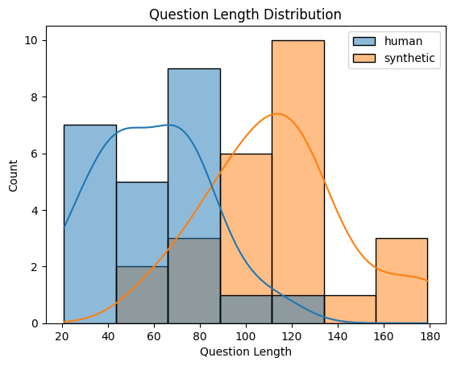

```python
question_length = {
    "human": human_eval_df["question"].map(len),
    "synthetic": synthetic_eval_df["question"].map(len)
}

sns.histplot(question_length, kde=True)
plt.title("Question Length Distribution")
plt.xlabel("Question Length")
plt.ylabel("Count")
plt.show()
```

```python
eval_df = pd.concat([human_eval_df, synthetic_eval_df], ignore_index=True)
eval_df["is_synthetic"] = eval_df["relevant_section"].isna()
eval_df["is_synthetic"].value_counts()
```

| is_synthetic | count |
| --- | --- |
| True | 25 |
| False | 23 |

**dtype:** int64

### RAGAS Metrics

RAGAS provides a variety of metrics to evaluate the performance of a RAG pipeline. Here are some of the key metrics we will be using and how they are calculated:

- [Answer Relevancy](https://docs.ragas.io/en/stable/concepts/metrics/answer_relevance.html): This metric measures the relevance of the generated answer to the user query. The Answer Relevancy is defined as the mean cosine similartiy of the original question to a number of artifical questions, which where generated (reverse engineered) based on the answer.
- [Answer Correctness](https://docs.ragas.io/en/stable/concepts/metrics/answer_correctness.html): This metric measures the correctness of the generated answer. Answer correctness encompasses two critical aspects: semantic similarity between the generated answer and the ground truth, as well as factual similarity. These aspects are combined using a weighted scheme to formulate the answer correctness score.
- [Faithfulness](https://docs.ragas.io/en/stable/concepts/metrics/faithfulness.html): This metric measures how well the generated answer is faithful to the retrieved chunks. The generated answer is regarded as faithful if all the claims that are made in the answer can be inferred from the given context. To calculate this a set of claims from the generated answer is first identified. Then each one of these claims are cross checked with given context to determine if it can be inferred from given context or not.
- [Context Relevancy](https://docs.ragas.io/en/stable/concepts/metrics/context_relevancy.html): This metric measures the relevance of the retrieved chunks to the user query. Ideally, the retrieved context should exclusively contain essential information to address the provided query. To compute this, we initially estimate the number of sentences within the retrieved context that are relevant for answering the given question and devide it by the total number of sentences in the retrieved context.

[figure not shown]

For this to work we create a test dataset for each of our RAG pipelines that contains the evaluation questions and their ground truth answers. We then run all the questions through our RAG pipeline and store the generated answers and the retrieved chunks. We can then use this test dataset to calculate the RAGAS metrics.

```python
datasets_folder = gold_folder / "datasets"
if not datasets_folder.exists():
    datasets_folder.mkdir()

def get_or_create_eval_dataset(name: str, df: pd.DataFrame, chain: Chain) -> Dataset:
    dataset_file = datasets_folder/ f"{name}_dataset.json"
    if dataset_file.exists():
        with open(dataset_file, "r") as file:
            dataset = Dataset.from_dict(json.load(file))
        print(f"Loaded {name} dataset from {dataset_file}")
    else:
        datapoints = {
            "question": df["question"].tolist(),
            "answer": [],
            "contexts": [],
            "ground_truth": df["ground_truth"].tolist(),
            "context_urls": []
        }
        for question in tqdm(datapoints["question"]):
            result = chain.invoke(question)
            datapoints["answer"].append(result["answer"])
            datapoints["contexts"].append([str(doc.page_content) for doc in result["context"]])
            # Check if 'url' exists in doc.metadata before accessing it
            datapoints["context_urls"].append([doc.metadata.get("url", "") for doc in result["context"]])
        dataset = Dataset.from_dict(datapoints)
        with open(dataset_file, "w") as file:
            json.dump(dataset.to_dict(), file)
        print(f"Saved {name} dataset to {dataset_file}")
    return dataset
```

```python
results_folder = gold_folder / "results"
if not results_folder.exists():
    results_folder.mkdir()

def get_or_run_llm_eval(name: str, dataset: Dataset, llm_judge_model: LLM) -> pd.DataFrame:
    eval_results_file = f"data/gold/{name}_llm_eval_results.csv"
    if os.path.exists(eval_results_file):
        eval_results = pd.read_csv(eval_results_file)
        print(f"Loaded {name} evaluation results from {eval_results_file}")
    else:
        # Pass raise_exceptions=False directly to evaluate
        eval_results = evaluate(dataset,
                                metrics=[faithfulness, answer_relevancy, context_relevancy, answer_correctness],
                                is_async=True,
                                llm=llm_judge_model,
                                raise_exceptions=False)  # Pass here
        eval_results.df.to_csv(eval_results_file, index=False)
        print(f"Saved {name} evaluation results to {eval_results_file}")
    return eval_results.df
```

```python
def plot_llm_eval(name: str, eval_results: pd.DataFrame):
    # select only the float64 columns (assuming these are the RAGAS metrics)
    ragas_metrics_data = (eval_results
                        .select_dtypes(include=[np.float64]))


    # boxplot of distributions
    sns.boxplot(data=ragas_metrics_data, palette="Set2")
    plt.title(f'{name}: Distribution of RAGAS Evaluation Metrics')
    plt.ylabel('Scores')
    plt.xlabel('Metrics')
    plt.xticks(rotation=45)
    plt.tight_layout()
    plt.show()

    # barplot of means
    means = ragas_metrics_data.mean()
    plt.figure(figsize=(14, 8))
    sns.barplot(x=means.index, y=means, palette="Set2")
    plt.title(f'{name}: Mean of RAGAS Evaluation Metrics')
    plt.ylabel('Mean Scores')
    plt.xlabel('Metrics')
    plt.xticks(rotation=45)

    plt.tight_layout()
    plt.show()
```

```python
def plot_multiple_evals(eval_results: Dict[str, pd.DataFrame]):
    # combine the results
    full_results = []
    for name, results in eval_results.items():
        results['name'] = name
        full_results.append(results)

    full_results = pd.concat(full_results, ignore_index=True)
    full_results = full_results.sort_values(by='name')


    # select only the float64 columns (assuming these are the RAGAS metrics)
    ragas_metrics_data = full_results.select_dtypes(include=[np.float64])
    ragas_metrics_data['name'] = full_results['name']

    # boxplot of distributions
    plt.figure(figsize=(14, 8))
    sns.boxplot(x='variable', y='value', hue='name', data=pd.melt(ragas_metrics_data, id_vars='name'), palette="Set2")
    plt.title('Distribution of RAGAS Evaluation Metrics by Model')
    plt.ylabel('Scores')
    plt.xlabel('Metrics')
    plt.xticks(rotation=45)
    plt.legend(title='Model')
    plt.tight_layout()
    plt.show()

    # barplot of means
    means = ragas_metrics_data.groupby('name').mean().reset_index()
    means_melted = pd.melt(means, id_vars='name')

    plt.figure(figsize=(14, 8))
    sns.barplot(x='variable', y='value', hue='name', data=means_melted, palette="Set2")
    plt.title('Mean of RAGAS Evaluation Metrics by Model')
    plt.ylabel('Mean Scores')
    plt.xlabel('Metrics')
    plt.xticks(rotation=45)
    plt.legend(title='Model')
    plt.tight_layout()
    plt.show()
```

```python
human_eval_dfs.keys()
```

```
dict_keys(['human_eval', 'media_cleaned', 'patent_cleaned', 'media', 'patent'])
```

```python
eval_df = human_eval_dfs['media_cleaned'].iloc[:5]
eval_df.columns
```

```
Index(['id', 'relevant_section', 'question', 'answer', 'url', 'category',
       'groundedness_score', 'groundedness_eval', 'relevance_score',
       'relevance_eval', 'standalone_score', 'standalone_eval'],
      dtype='object')
```

```python
eval_df= eval_df.rename(columns = {"answer":"ground_truth","context":"contexts", "source_doc":"context_urls"})
```

```python
eval_df.columns
```

```
Index(['id', 'relevant_section', 'question', 'ground_truth', 'url', 'category',
       'groundedness_score', 'groundedness_eval', 'relevance_score',
       'relevance_eval', 'standalone_score', 'standalone_eval'],
      dtype='object')
```

```python
selected_dataset = get_or_create_eval_dataset("generated_questions", eval_df, selected_chain)
```

```
Saved generated_questions dataset to data/gold/datasets/generated_questions_dataset.json
```

```python
selected_dataset = get_or_create_eval_dataset("selected", eval_df, selected_chain)
```

```
Loaded selected dataset from data/gold/datasets/selected_dataset.json
```

It has also been suggest in Literature that when evaluating LLMs with LLMS as judges the evaluation is more reliable when the judge a different model than the model being evaluated. This is because the models might have learned to exploit the weaknesses of the other model or have a certain bias to there own answers. https://arxiv.org/abs/2404.13076

```python
judge = ChatOpenAI(model="gpt-4o-mini")
question_prompt = ChatPromptTemplate.from_template(
    "Answer the following question: {question}")
question_chain = question_prompt | judge | StrOutputParser()
question_chain.invoke({"question": "What is the meaning of life?"})
```

```
"The meaning of life is a profound and subjective question that varies greatly from person to person. Different cultures, religions, philosophies, and individuals offer a range of interpretations. Some might find meaning through relationships, love, and family, while others may seek purpose in achie…
```

```python
selected_llm_eval_results = get_or_run_llm_eval("generated_questions", selected_dataset, llm)
plot_llm_eval("generated_questions_cleaned", selected_llm_eval_results)
```

[output not shown]

```python
datasets = {}
for name, chain in chains.items():
    datasets[name] = get_or_create_eval_dataset(name, eval_df, chain)
```

```python
llm_results = {}
for dataset_name, dataset in datasets.items():
    llm_results[dataset_name] = get_or_run_llm_eval(dataset_name, dataset, llm)
```

```python
plot_multiple_evals(llm_results)
```

[output not shown]

```python
mean_scores = {}
for name, results in llm_results.items():
    mean_scores[name] = results.select_dtypes(include=[np.float64]).mean()

total_mean_scores = pd.DataFrame(mean_scores).mean()
total_mean_scores.sort_values(ascending=False)
```

[output not shown]

```python
# best_collection = collections["gte_recursive_1024"]
# best_store = collection_to_store("gte_recursive_1024", embedding_models["gte"])
```

[output not shown]

### As an Improvement we suggest to reform the query to extract even more meaningfull chunks

```python
from langchain.schema import BaseRetriever
from langchain.chains import LLMChain
from langchain.prompts import PromptTemplate

# 1) Your small “rewrite this query” LLMChain
rewrite_template = PromptTemplate(
    input_variables=["original_query"],
    template=(
        "Rewrite the following query using more technical cleantech and patent-related terminology:\n\n"
        "User Query: {original_query}\n"
        "Rewritten Query:"
    )
)
rewriter_chain = LLMChain(llm=llm, prompt=rewrite_template)

class QueryRewritingRetriever:
    def __init__(self, base_retriever: BaseRetriever, rewriter: LLMChain):
        self.base_retriever = base_retriever
        self.rewriter = rewriter

    def get_relevant_documents(self, query: str):
        rewritten_q = self.rewriter.run(original_query=query).strip()
        return self.base_retriever.get_relevant_documents(rewritten_q)

    def __call__(self, query: str):
        return self.get_relevant_documents(query)
```

```python
# 3) Wire it into your existing pipeline
# selected_store     = collection_to_store("gte_recursive_1024", embedding_models["gte"])
# base_retriever     = store_to_retriever(selected_store, k=3)

collection_name = "gte_recursive_1024"
base_retriever = collection_to_hybrid_retriever(collections[collection_name], candidate_k=50, final_k=3)


wrapping_retriever = QueryRewritingRetriever(base_retriever, rewriter_chain)

selected_chain = create_qa_chain(wrapping_retriever)

# 4) Now invoke exactly as before:
answer = selected_chain.invoke(
    "Where are the biggest increases in wildfire smoke exposure in recent years?"
)
print(answer)
```

[output not shown]

```python
chains = {
  emb_name: create_qa_chain(
               QueryRewritingRetriever(
                 collection_to_hybrid_retriever(collections[emb_name], candidate_k=50, final_k=3),
                 rewriter_chain
               )
            )
  for emb_name in embedding_models
}

datasets = {
  name: get_or_create_eval_dataset(name, eval_df, chain)
  for name, chain in chains.items()
}
llm_results = {
  name: get_or_run_llm_eval(name, dataset, judge)
  for name, dataset in datasets.items()
}
```

```python
plot_multiple_evals(llm_results)
```

[output not shown]

```python
mean_scores = {}
for name, results in llm_results.items():
    mean_scores[name] = results.select_dtypes(include=[np.float64]).mean()

total_mean_scores = pd.DataFrame(mean_scores).mean()
total_mean_scores.sort_values(ascending=False)
```

[output not shown]

## Advanced Methods

### Multi-Querying

[figure not shown]

## Multi-Querying

In the original implementation multi query retrieval was suggested as one of the improvements approached. Multi query retrieval uses an LLM to generate multiple reformulations or perspectives of the user’s query. Instead of relying on a single query embedding, the system issues several different queries and aggregates the results. This approach helps mitigate sensitivity to wording minor phrasing changes can surface different relevant documents. While multiquerying increases the chance of finding relevant information especially for vague queries, it can also introduce redundancy or noise. If the queries are too similar, they may retrieve overlapping results, providing little new information. Conversely, poorly guided query generation might produce irrelevant queries that pull in off topic documents, which could confuse the answer generation. To mitigate this issue we could emphasize to the maximal difference between the generated sub queries to cover various aspects of the information need. Recent research suggests that multi aspect query generation improves retrieval performance when combined with strong retrievers ([Learned Sparse Retrieval with Multi-aspect LLM Query Generation](https://arxiv.org/html/2411.14739v1#:~:text=Learned%20Sparse%20Retrieval%20with%20Multi,advanced%20retrieval%20and%20reranking%20models)). For example, *Seo & Lee (2025)* generate multiple distinct question variations and their hypothetical answers, then filter them, yielding a 13% boost in recall on benchmarks (Seo & Lee, 2025) ([QA-Expand: Multi-Question Answer Generation for Enhanced Query Expansion in Information Retrieval](https://arxiv.org/abs/2502.08557#:~:text=retrieve%20all%20relevant%20information,solution%20for%20modern%20retrieval%20challenges)). Guiding the LLM to produce queries targeting different subtopics or interpretations of the question ensures greater diversity in retrieved content.  
Another way to improve the mutli query approach would be to introduce a filtering or ranking step to handle the results from multiple queries. One can use a cross encoder or LLM based scorer to rerank the union of all retrieved documents by relevance to the original question. This helps discard irrelevancies and merge duplicates. By evaluating each candidate passage in context (e.g. with a BERT based cross encoder), the system can prioritize information that directly answers the query, improving precision (Nogueira & Cho, 2019). Such re-ranking can be integrated into the pipeline so that only the top unique supporting evidence from all queries is fed to the generator.

Last but not least the multi-query module itself can be made iterative. The LLM could initially generate a batch of queries, retrieve documents, then refine or add new queries based on what was missing in the results. For example, if none of the retrieved documents address a particular facet of the question, the system can prompt the LLM to generate a follow up query for that subtopic. This feedback loop ensures more complete coverage of complex queries. Research on retrieval with feedback (Asai et al., 2023) shows that LLMs can self-reflect on the adequacy of retrieved evidence and formulate new queries to fill gaps, improving overall answer accuracy (Asai et al., 2023).

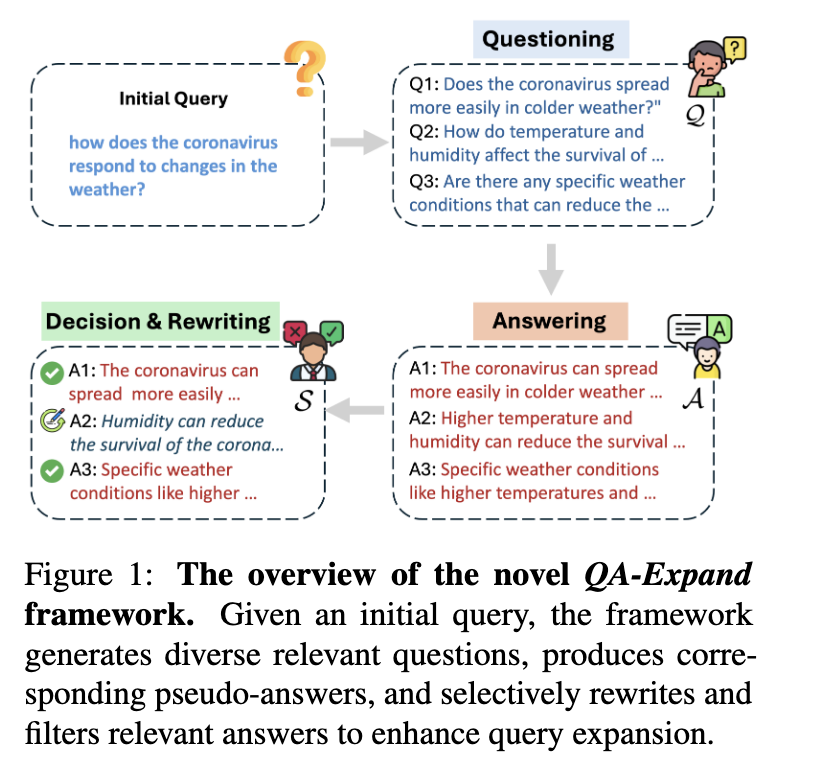

Fig. 1. “Overview of the QA-Expand Framework.” *QA-Expand: Multi-Question Answer Generation for Enhanced Query Expansion in Information Retrieval,* by Wonduk Seo and Seunghyun Lee, arXiv, 2025, arXiv:2502.08557, https://arxiv.org/abs/2502.08557.

```python
def generate_query_variations(query: str, num_additional_queries: int) -> List[str]:
    multiquery_prompt = """You are an assistant tasked with generating {num_queries} \
    different versions of the given user question to retrieve relevant documents from a vector \
    database. By generating multiple perspectives on the user question and breaking it down, your goal is to help \
    the user overcome some of the limitations of the distance-based similarity search. \
    Provide these alternative questions separated by newlines without any numbering or listing.
    Original question: {question}
    Alternatives:
    """

    multiquery_chain = ChatPromptTemplate.from_template(multiquery_prompt) | llm
    return multiquery_chain.invoke({"question": query, "num_queries": num_additional_queries}).content.split("\n")
```

```python
def get_vectors_from_collection(collection: Collection):
    stored_chunks = collection.get(include=["documents", "metadatas", "embeddings"])
    return np.array(stored_chunks["embeddings"])


def fit_umap(vectors: np.ndarray):
    return umap.UMAP().fit(vectors)

def project_embeddings(embeddings, umap_transform):
    return umap_transform.transform(embeddings)
```

```python
def plot_multiquery_retrieval_results(query: str, collection : Collection, num_additional_queries: int = 3, num_results: int = 3):
    vectors = get_vectors_from_collection(collection)
    umap_transform = fit_umap(vectors)
    vectors_projections = project_embeddings(vectors, umap_transform)

    query_projections = project_embeddings(collection._embedding_function([query]), umap_transform)

    query_variations = generate_query_variations(query, 5)
    query_variations_projections = project_embeddings(collection._embedding_function(query_variations), umap_transform)

    original_relevant_docs = collection.query(
        query_texts=[query],
        n_results=num_results,
    )
    original_relevant_docs_ids = [item for sublist in original_relevant_docs["ids"] for item in sublist] # flatten
    original_relevant_docs_embeddings = collection.get(include=["embeddings"], ids=original_relevant_docs_ids)["embeddings"]
    original_relevant_docs_projections = project_embeddings(original_relevant_docs_embeddings, umap_transform)

    additional_relevant_docs = collection.query(
        query_texts=query_variations,
        n_results=num_results,
    )
    additional_relevant_docs_ids = [item for sublist in additional_relevant_docs["ids"] for item in sublist] # flatten
    # remove duplicates
    additional_relevant_docs_ids = list(set(additional_relevant_docs_ids))
    # remove the original relevant docs from the additional relevant docs
    additional_relevant_docs_ids = [doc_id for doc_id in additional_relevant_docs_ids if doc_id not in original_relevant_docs_ids]
    additional_relevant_docs_embeddings = collection.get(include=["embeddings"], ids=additional_relevant_docs_ids)["embeddings"]
    additional_relevant_docs_projections = project_embeddings(additional_relevant_docs_embeddings, umap_transform)

    fig = go.Figure()

    fig.add_trace(go.Scatter(x=vectors_projections[:, 0], y=vectors_projections[:, 1], mode='markers', marker=dict(size=5), name="other vectors"))
    fig.add_trace(go.Scatter(x=query_projections[:, 0], y=query_projections[:, 1], mode='markers', marker=dict(size=7, color='black', symbol='x'), name="original query"))
    fig.add_trace(go.Scatter(x=query_variations_projections[:, 0], y=query_variations_projections[:, 1], mode='markers', marker=dict(size=7, color='red', symbol='x'), name="query variations"))
    fig.add_trace(go.Scatter(x=original_relevant_docs_projections[:, 0], y=original_relevant_docs_projections[:, 1], mode='markers', marker=dict(size=7, color='orange'), name="original relevant docs"))
    fig.add_trace(go.Scatter(x=additional_relevant_docs_projections[:, 0], y=additional_relevant_docs_projections[:, 1], mode='markers', marker=dict(size=7, color='green'), name="additional relevant docs"))

    fig.show(renderer="colab")
```

```python
plot_multiquery_retrieval_results("Climate Change", selected_collection)
```

[output not shown]

```python
class MultiQueryRetriever(BaseRetriever):
    collection_name: str
    num_additional_queries: int = 3
    num_results: int = 3

    def _get_query_variations(self, query: str) -> List[str]:
       return generate_query_variations(query, self.num_additional_queries)

    def _get_relevant_documents(
        self, original_query: str, *, run_manager: CallbackManagerForRetrieverRun
    ) -> List[Document]:
        queries = self._get_query_variations(original_query)
        queries.append(original_query)
        # retriever = store_to_retriever(self.store, k=self.num_results)
        retriever = collection_to_hybrid_retriever(collections[collection_name], candidate_k=50, final_k=3)
        relevant_docs = []
        for query in queries:
            results = retriever.invoke(query, run_manager=run_manager)
            # remove duplicates
            for res in results:
                if res not in relevant_docs:
                    relevant_docs.append(res)
        return relevant_docs
```

```python
multiquery_retriever = MultiQueryRetriever(collection_name = collection_name, num_additional_queries=3, num_results=3)
multiquery_chain = create_qa_chain(multiquery_retriever)
multiquery_chain.invoke("Where are the biggest increases in wildfire smoke exposure in recent years?")
```

[output not shown]

```python
datasets["multiquery"] = get_or_create_eval_dataset("multiquery", eval_df, multiquery_chain)
```

```python
llm_results["multiquery"] = get_or_run_llm_eval("multiquery", datasets["multiquery"], llm)
```

```python
strategy_results = {}
strategy_results["gte_recursive_1024"] = llm_results["gte_recursive_1024"]
strategy_results["multiquery"] = llm_results["multiquery"]
plot_multiple_evals(strategy_results)
```

[output not shown]

### HyDE - Hypothetical Document Embeddings

[figure not shown]

## Hypothetical Document Embeddings (HyDE)

HyDE is a technique where the system prompts an LLM to imagine a hypothetical document or answer for the query, then uses that generated text for retrieval. Instead of embedding the original query (which may be short or ambiguous), HyDE embeds the richer, LLM-generated content and finds real documents similar to it. HyDE can bridge the gap when exact matches for the query are absent,so the imagined document adds context and keywords that guide the retriever to relevant info (Gao et al., 2022). However, its effectiveness depends on the quality of the hypothetical answer. If the LLM introduces speculative or incorrect details, the retriever might fetch documents that match the hallucination rather than factual references. Another limitation is that a single hypothetical document may cover only one interpretation of the query. For ambiguous questions, a one shot guess might miss the mark, leading the retrieval astray.

To mitigate this issue, instead of generating one hypothetical document, generate several hypothetical passages, each approaching the query from a different perspective. This increases the odds that at least one will align with the actual relevant content. Recent work on query expansion supports using multiple generated contexts: e.g. generating multiple Q&A pairs as pseudo documents and then filtering them led to significantly better recall than a single expansion (Seo & Lee, 2025) ( QA-Expand: Multi-Question Answer Generation for Enhanced Query Expansion in Information Retrieval)(https://arxiv.org/pdf/2502.08557). The pipeline can embed all hypothetical documents and retrieve for each, then merge the results. This multi hypothesis HyDE ensures that different possible interpretations or answers are explored, improving recall diversity.

In parallel, we can introduce a verification step for the hypothetical document before using it to search. For instance, the system might do a quick check of whether key terms in the generated passage actually cooccur in the knowledge corpus (a sign the hypothetical content is plausible). If the hypothetical is too far fetched (no matching documents at all), the LLM could be prompted to revise it. Another approach is to prompt the LLM to generate the hypothetical text using a chain-of-thought, which may result in a more coherent and grounded document. Ensuring the hypothetical answer stays on-topic (perhaps by constraining the LLM with retrieved keywords if available) can lead to more precise embeddings.

```python
def generate_hypothetical_document(query: str, num_hypotheses: int) -> List[str]:
    hyde_prompt = """Please write a news passage about the topic.
    Topic: {query}
    Passage:
    """

    hyde_chain = ChatPromptTemplate.from_template(hyde_prompt) | llm
    hypothetical_documents = [hyde_chain.invoke({"query": query}).content for _ in range(num_hypotheses)]
    return hypothetical_documents
```

```python
def plot_hyde_retrieval_results(query: str, collection : Collection, num_hypo_documents: int = 2, num_results: int = 3):
    vectors = get_vectors_from_collection(collection)
    umap_transform = fit_umap(vectors)
    vectors_projections = project_embeddings(vectors, umap_transform)

    query_projections = project_embeddings(collection._embedding_function([query]), umap_transform)

    hypothetical_documents = generate_hypothetical_document(query, num_hypo_documents)
    query_variations_projections = project_embeddings(collection._embedding_function(hypothetical_documents), umap_transform)

    original_relevant_docs = collection.query(
        query_texts=[query],
        n_results=num_results,
    )
    original_relevant_docs_ids = [item for sublist in original_relevant_docs["ids"] for item in sublist] # flatten
    original_relevant_docs_embeddings = collection.get(include=["embeddings"], ids=original_relevant_docs_ids)["embeddings"]
    original_relevant_docs_projections = project_embeddings(original_relevant_docs_embeddings, umap_transform)

    additional_relevant_docs = collection.query(
        query_texts=hypothetical_documents,
        n_results=num_results,
    )
    additional_relevant_docs_ids = [item for sublist in additional_relevant_docs["ids"] for item in sublist] # flatten
    # remove duplicates
    additional_relevant_docs_ids = list(set(additional_relevant_docs_ids))
    # remove the original relevant docs from the additional relevant docs
    additional_relevant_docs_ids = [doc_id for doc_id in additional_relevant_docs_ids if doc_id not in original_relevant_docs_ids]
    additional_relevant_docs_embeddings = collection.get(include=["embeddings"], ids=additional_relevant_docs_ids)["embeddings"]
    additional_relevant_docs_projections = project_embeddings(additional_relevant_docs_embeddings, umap_transform)

    fig = go.Figure()

    fig.add_trace(go.Scatter(x=vectors_projections[:, 0], y=vectors_projections[:, 1], mode='markers', marker=dict(size=5), name="other vectors"))
    fig.add_trace(go.Scatter(x=query_projections[:, 0], y=query_projections[:, 1], mode='markers', marker=dict(size=7, color='black', symbol='x'), name="original query"))
    fig.add_trace(go.Scatter(x=query_variations_projections[:, 0], y=query_variations_projections[:, 1], mode='markers', marker=dict(size=7, color='red', symbol='x'), name="hypothetical documents"))
    fig.add_trace(go.Scatter(x=original_relevant_docs_projections[:, 0], y=original_relevant_docs_projections[:, 1], mode='markers', marker=dict(size=7, color='orange'), name="original relevant docs"))
    fig.add_trace(go.Scatter(x=additional_relevant_docs_projections[:, 0], y=additional_relevant_docs_projections[:, 1], mode='markers', marker=dict(size=7, color='green'), name="additional relevant docs"))

    fig.show(renderer="colab")
```

```python
plot_hyde_retrieval_results("Climate Change", selected_collection)
```

[output not shown]

```python
class HyDERetriever(BaseRetriever):
    collection_name: str
    num_hypo_documents: int = 2
    num_results: int = 3

    def _get_hypothetical_documents(self, query: str) -> List[str]:
        return generate_hypothetical_document(query, self.num_hypo_documents)

    def _get_relevant_documents(
        self, original_query: str, *, run_manager: CallbackManagerForRetrieverRun
    ) -> List[Document]:
        hypothetical_documents = self._get_hypothetical_documents(original_query)
        hypothetical_documents.append(original_query)
        retriever = collection_to_hybrid_retriever(collections[collection_name], candidate_k=50, final_k=3)
        # retriever = store_to_retriever(self.store, k=self.num_results)
        relevant_docs = []
        for query in hypothetical_documents:
            results = retriever.invoke(query, run_manager=run_manager)
            # remove duplicates
            for res in results:
                if res not in relevant_docs:
                    relevant_docs.append(res)
        return relevant_docs
```

```python
hyde_retriever = HyDERetriever(collection_name = collection_name, k=3)
hyde_chain = create_qa_chain(hyde_retriever)
hyde_chain.invoke("Where are the biggest increases in wildfire smoke exposure in recent years?")
```

[output not shown]

```python
datasets["hyde"] = get_or_create_eval_dataset("hyde", eval_df, hyde_chain)
```

```python
llm_results["hyde"] = get_or_run_llm_eval("hyde", datasets["hyde"], llm)
```

```python
strategy_results["hyde"] = llm_results["hyde"]
plot_multiple_evals(strategy_results)
```

[output not shown]

### Other Methods

There are many other methods that can be used to improve the RAG pipeline. Some of these include:

```python
os.system("jupyter nbconvert --to html --template pj cleantech_rag.ipynb")
```